# Lyft Bay Wheel's trip dataset exploration

## by Hyunbyung, Park

> Lyft operate bike sharing service around bay area and collected the data related to this bike sharing service. This dataset is consisted with the trip data using bike like location, time, and which bike was used opened to the public. Every trip data is anonymized.

**The project is consisted with the following part**

## Part 1. Loading Lyft Bay Wheel's trip dataset ✅

- A. Gathering ✅
- B. Assessing ✅
- C. Cleaning ✅
- D. Storing ✅
- E. Analyze & Plan ✅

## Part 2. Exploring the data with visualization

- A. Univariate Exploration ✅
- B. Bivariate Exploration ✅
- C. Multivariate Exploration ✅

```python
# import all packages and set plots to be embedded inline
import os
import numpy as np
import pandas as pd
import matplotlib.pyplot as plt
import seaborn as sb

%matplotlib inline
```

```python
# upgrade the pandas to newest version
!pip install --user --upgrade pandas
```

## Part 1. Loading Lytf Bay Wheel's trip dataset ✅

> We need to download the dataset from https://www.lyft.com/bikes/bay-wheels/system-data and wrangle it!

We are going to download the dataset programmatically using [Request](https://pypi.org/project/requests) library. To handle html file we are going to use [Beautifulsoup](https://pypi.org/project/beautifulsoup4/). After assessing the dataset we are going to clean the quality and tidy issues.

- A. Gathering
- B. Assessing
- C. Cleaning
- D. Storing
- E. Analyze & Plan

## A. Gathering ✅

1. Find the archive url from the main bike page
2. Download the dataset from archive
   - requests ❌ **No javascript rendering supported**
   - requests_html ❌ **javascript rendering supported but crash due to occupied eventloop used by jupyter notebook**
   - selenium ✔️ **Works great but need chromedriver**
3. Unzip the dataset and merge to one csv file

```python
# import library for parsing (one-time usage)
import requests
from bs4 import BeautifulSoup
import re
```

### 1. Find the archive url from the main bike page

```python
bikedata_mainpage_url = 'https://www.lyft.com/bikes/bay-wheels/system-data'

# Get the html data from the url using request
bikedata_mainpage = requests.get(bikedata_mainpage_url)

# wrap the html data with beautifulsoup
soup = BeautifulSoup(bikedata_mainpage.text, 'html.parser')

# Select the url heading to dataset archive from lyft bike main page
data_selected = soup.select('#react-app > div > article > span > section > div.Grid-sc-132wtts-0.jxHymG > div.Container-q480ss-0.dmasbq > div > div:nth-child(6) > p > a')
archive_url = data_selected[0].attrs['href']

# Another way to get the url using the regex expression
archive_url = soup.find_all(text=re.compile('^Download Bay Wheels trip history data'))[0].parent.parent.attrs['href']
```

### 2. Download the dataset from archive

- requests ❌
- requests_html ❌
- selenium ✔️

**requests** ❌

```python
# Get the html data for the dataset page
data_archive_page = requests.get(archive_url)

# wrap the html data with beautifullsoup
soup = BeautifulSoup(data_archive_page.text, 'html.parser')

# Nothing is found WHY?
soup.find_all(text=re.compile('csv.zip'))
```

```
[]
```

```python
archive_url
```

```
'https://s3.amazonaws.com/baywheels-data/index.html'
```

The problem here is that the https://s3.amazonaws.com/baywheels-data/index.html page data is loaded using javascript. So when we use requests library it parse the html data before the javascript was used. We have to use different library that supports javascript rendering.

**requests_html** ❌

```python
# Download a new library for data
!pip install requests_html
!pip install nest_asyncio
```

```python
import asyncio
from requests_html import HTMLSession

session = HTMLSession()
data_archive_page = session.get(archive_url)

if asyncio.get_event_loop().is_running():
    import nest_asyncio
    nest_asyncio.apply()
```

```python
data_archive_page.html.render()
```

```
---------------------------------------------------------------------------
RuntimeError                              Traceback (most recent call last)
<ipython-input-43-c9f422f25e36> in <module>
----> 1 data_archive_page.html.render()

~\anaconda3\lib\site-packages\requests_html.py in render(self, retries, script, wait, scrolldown, sleep, reload, timeout, keep_page)
    584         """
    585
--> 586         self.browser = self.session.browser  # Automatically create a event loop and browser
    587         content = None
    588

~\anaconda3\lib\site-packages\requests_html.py in browser(self)
    727             self.loop = asyncio.get_event_loop()
    728             if self.loop.is_running():
--> 729                 raise RuntimeError("Cannot use HTMLSession within an existing event loop. Use AsyncHTMLSession instead.")
    730             self._browser = self.loop.run_until_complete(super().browser)
    731         return self._browser

RuntimeError: Cannot use HTMLSession within an existing event loop. Use AsyncHTMLSession instead.
```

Due to eventloop problem `HTMLSession` is not working. Also the `AsyncHTMLSession` didn't worked as well. There is 2 options right know.

1. Write a python script outside the jupyter notebook
2. Use selenium

I wanted to exclude the work outside the jupyter notebook as possible as I can so I worked with selenium. This requires **chromedriver**.

**selenium** ✔️

```python
!pip install selenium
```

```python
from selenium import webdriver

# The chromeversion is 83 and the driver is also for 83 version
# This part I manually download the chrome driver
chromedriver_path = 'chromedriver.exe'
driver = webdriver.Chrome(chromedriver_path)
```

```python
# open the webpage
driver.get(archive_url)
```

```python
# Get the html data using selenium
html = driver.page_source

# wrap the html data with beautifulsoup
soup = BeautifulSoup(html, 'html.parser')

# Get way to get the url using the regex expression
csv_list = soup.find_all(text=re.compile('csv.zip'))
```

We are going to save the files to `data` folder.

```python
# generate new folder name "data" if there is no folder name "data" exist
dataset_path = 'data'
if not os.path.isdir(dataset_path):
    os.mkdir(dataset_path)

for csv in csv_list:
    # Use the filename as it was indicated in the homepage
    url = csv.parent.attrs['href']
    filename = url.split('/')[-1]

    # Request the data programmatically
    try:
        response = requests.get(url)
        with open(os.path.join(dataset_path, filename), mode='wb') as f:
             f.write(response.content)
    except requests.exceptions.RequestException as e:
        raise SystemExit(e)
```

```python
# shut down the webpage
driver.quit()
```

### 3. Unzip the dataset and merge to one csv file

The files are all consisted with zip files so we need to unzip it and merge it to one dataset

```python
import zipfile
import io
```

```python
dataset_path = 'data'

# check the dataset folder exist
if not os.path.isdir(dataset_path):
    raise FileNotFoundError("There is no dataset folder called 'data'")

# We are not going to extract the zip file
# Rather we are just going to open one zip file by one and read the content
# and wrap it with pandas DataFrame to make one big merged csv file
# includes every content of all the zip files

# The list where we are going to store all the csv files
all_csv_list = []

for data in os.listdir(dataset_path):
    # zip file path
    source_file = os.path.join(dataset_path, data)

    # Wrap the zip file with Zipfile library
    with zipfile.ZipFile(source_file, 'r') as zf:

        # Open the content without extracting the zip file
        with zf.open('.'.join(data.split('.')[:-1])) as f:

            # Read the content. This is binary datatype
            binary = f.read()

            # Decode the binary file by utf-8. This will return string
            utf8_str = binary.decode('utf-8')

            # To use pandas read_csv change string to string file using io.StringIO
            str_file = io.StringIO(utf8_str)

            # Wrap the content with pandas DataFrame temporarily.
            # We are going to store the csv file to one master csv file
            tmp_csv = pd.read_csv(str_file)

            # Append to the list
            all_csv_list.append(tmp_csv)
```

```python
# Check the csv list for a while
all_csv_list[2].head(5)
```

|  | duration_sec | start_time | end_time | start_station_id | start_station_name | start_station_latitude | start_station_longitude | end_station_id | end_station_name | end_station_latitude | end_station_longitude | bike_id | user_type | bike_share_for_all_trip |
| --- | --- | --- | --- | --- | --- | --- | --- | --- | --- | --- | --- | --- | --- | --- |
| 0 | 598 | 2018-02-28 23:59:47.0970 | 2018-03-01 00:09:45.1870 | 284 | Yerba Buena Center for the Arts (Howard St at ... | 37.784872 | -122.400876 | 114 | Rhode Island St at 17th St | 37.764478 | -122.402570 | 1035 | Subscriber | No |
| 1 | 943 | 2018-02-28 23:21:16.4950 | 2018-02-28 23:36:59.9740 | 6 | The Embarcadero at Sansome St | 37.804770 | -122.403234 | 324 | Union Square (Powell St at Post St) | 37.788300 | -122.408531 | 1673 | Customer | No |
| 2 | 18587 | 2018-02-28 18:20:55.1900 | 2018-02-28 23:30:42.9250 | 93 | 4th St at Mission Bay Blvd S | 37.770407 | -122.391198 | 15 | San Francisco Ferry Building (Harry Bridges Pl... | 37.795392 | -122.394203 | 3498 | Customer | No |
| 3 | 18558 | 2018-02-28 18:20:53.6210 | 2018-02-28 23:30:12.4500 | 93 | 4th St at Mission Bay Blvd S | 37.770407 | -122.391198 | 15 | San Francisco Ferry Building (Harry Bridges Pl... | 37.795392 | -122.394203 | 3129 | Customer | No |
| 4 | 885 | 2018-02-28 23:15:12.8580 | 2018-02-28 23:29:58.6080 | 308 | San Pedro Square | 37.336802 | -121.894090 | 297 | Locust St at Grant St | 37.322980 | -121.887931 | 1839 | Subscriber | Yes |

```python
# Concat all the csv files to one master csv file
# ignore_index ignore the original indebx
master_csv = pd.concat(all_csv_list, axis=0, ignore_index=True)

# save it to lyft_bay_wheel.csv file
master_csv.to_csv("lytf_bay_wheel.csv", index=False)
```

## B. Assessing ✅

> We concate all the datas to one master csv. Its time to get understanding of the datset and check the quality and tidy issues to be fixed
1. Visual assessment
2. Programmatic assessment
3. Tidiness issues
4. Quality issues

### 1. Visual assessment

```python
master_csv
```

|  | duration_sec | start_time | end_time | start_station_id | start_station_name | start_station_latitude | start_station_longitude | end_station_id | end_station_name | end_station_latitude | ... | ride_id | rideable_type | started_at | ended_at | start_lat | start_lng | end_lat | end_lng | member_casual | is_equity |
| --- | --- | --- | --- | --- | --- | --- | --- | --- | --- | --- | --- | --- | --- | --- | --- | --- | --- | --- | --- | --- | --- |
| 0 | 80110.0 | 2017-12-31 16:57:39.6540 | 2018-01-01 15:12:50.2450 | 74.0 | Laguna St at Hayes St | 37.776435 | -122.426244 | 43.0 | San Francisco Public Library (Grove St at Hyde... | 37.778768 | ... | NaN | NaN | NaN | NaN | NaN | NaN | NaN | NaN | NaN | NaN |
| 1 | 78800.0 | 2017-12-31 15:56:34.8420 | 2018-01-01 13:49:55.6170 | 284.0 | Yerba Buena Center for the Arts (Howard St at ... | 37.784872 | -122.400876 | 96.0 | Dolores St at 15th St | 37.766210 | ... | NaN | NaN | NaN | NaN | NaN | NaN | NaN | NaN | NaN | NaN |
| 2 | 45768.0 | 2017-12-31 22:45:48.4110 | 2018-01-01 11:28:36.8830 | 245.0 | Downtown Berkeley BART | 37.870348 | -122.267764 | 245.0 | Downtown Berkeley BART | 37.870348 | ... | NaN | NaN | NaN | NaN | NaN | NaN | NaN | NaN | NaN | NaN |
| 3 | 62172.0 | 2017-12-31 17:31:10.6360 | 2018-01-01 10:47:23.5310 | 60.0 | 8th St at Ringold St | 37.774520 | -122.409449 | 5.0 | Powell St BART Station (Market St at 5th St) | 37.783899 | ... | NaN | NaN | NaN | NaN | NaN | NaN | NaN | NaN | NaN | NaN |
| 4 | 43603.0 | 2017-12-31 14:23:14.0010 | 2018-01-01 02:29:57.5710 | 239.0 | Bancroft Way at Telegraph Ave | 37.868813 | -122.258764 | 247.0 | Fulton St at Bancroft Way | 37.867789 | ... | NaN | NaN | NaN | NaN | NaN | NaN | NaN | NaN | NaN | NaN |
| ... | ... | ... | ... | ... | ... | ... | ... | ... | ... | ... | ... | ... | ... | ... | ... | ... | ... | ... | ... | ... | ... |
| 6017916 | NaN | NaN | NaN | 485.0 | Funston Ave at Fulton St | NaN | NaN | 96.0 | Dolores St at 15th St | NaN | ... | BACC41F140A7114A | electric_bike | 2020-05-10 17:26:19 | 2020-05-10 17:46:18 | 37.7734 | -122.4713 | 37.7662 | -122.4267 | casual | False |
| 6017917 | NaN | NaN | NaN | NaN | NaN | NaN | NaN | NaN | NaN | NaN | ... | 64F4C06CB79B6205 | electric_bike | 2020-05-30 17:40:19 | 2020-05-30 17:47:50 | 37.7516 | -122.4309 | 37.7353 | -122.4227 | casual | False |
| 6017918 | NaN | NaN | NaN | 71.0 | Broderick St at Oak St | NaN | NaN | NaN | NaN | NaN | ... | C38F43B3BF11399F | electric_bike | 2020-05-31 12:34:41 | 2020-05-31 14:42:32 | 37.7730 | -122.4391 | 37.7974 | -122.4331 | casual | False |
| 6017919 | NaN | NaN | NaN | NaN | NaN | NaN | NaN | NaN | NaN | NaN | ... | 9C53113CA86194C5 | electric_bike | 2020-05-30 17:27:57 | 2020-05-30 17:46:56 | 37.7883 | -122.4090 | 37.7591 | -122.4253 | casual | False |
| 6017920 | NaN | NaN | NaN | NaN | NaN | NaN | NaN | NaN | NaN | NaN | ... | 6E047EDBF933A50B | electric_bike | 2020-05-31 13:49:41 | 2020-05-31 14:10:56 | 37.7909 | -122.4392 | 37.7909 | -122.4393 | casual | False |

6017921 rows × 25 columns

```python
master_csv.bike_share_for_all_trip.value_counts()
```

```
No     3787538
Yes     339907
Name: bike_share_for_all_trip, dtype: int64
```

There is **6017921** data of `usage of bikes` and each rows have **25** columns that seems duplicated

**columns**

📌 - Duplicated

- **duration_sec** - How long they used bike for trip (second)
- **start_time** - The time and date the user borrowed the bike
- **end_time** - The time and date the user returned the bike
- **start_station_id** - The ID allocated to the station where the user borrowed the bike
- **start_station_name** - The name of the station where the user borrowed the bike
- **start_station_latitude** - The latitude of the station the user borrowed the bike
- **start_station_longitude** - The longitude of the station where the user borrowed the bike
- **end_station_id** - The ID allocated to the station where the user returned the bike
- **end_station_name** - The name of the station where the user returned the bike
- **end_station_latitude** - The latitude of the station the user returned the bike
- **end_station_longitude** - The longitude of the station where the user returned the bike
- **bike_id** - The ID allocated to the bike which the user borrowed
- **user_type** - Is the user subscriber(member) of service or just casual user(Customer)?
- **bike_share_for_all_trip** - Is this trip used by [bike share for all](https://www.lyft.com/bikes/bay-wheels/bike-share-for-all) membership?
- **rental_access_method** - The method the user used to pay when they borrow the bike (app, clipper)
- **ride_id** - The allocated ID of each trip itself
- **rideable_type** - The type of bike (electric, docked)
- 📌 **started_at** - Same as `start_time`
- 📌 **ended_at** - Same as `end_time`
- 📌 **start_lat** - Same as `start_station_latitude`
- 📌 **start_lng** - Same as `start_station_longitude`
- 📌 **end_lat** - Same as `end_station_latitude`
- 📌 **end_lng** - Same as `end_station_longitude`
- 📌 **member_casual** - Same as `User_type`
- **is_equity** - The bike is equity of lyft?

### 2. Programmatic assessment

Now its time to check the information programmatically! Below is a common method used in pandas for programmatic assessment!

- **head** (DataFrame and Series)
- **tail** (DataFrame and Series)
- **sample** (DataFrame and Series)
- **info** (DataFrame only)
- **describe** (DataFrame and Series)
- **value_counts** (Series only)
- **duplicated** (DataFrame and Series)
- **Various methods of indexing and selecting data** (ex iloc, loc)

```python
master_csv.info()
```

```
<class 'pandas.core.frame.DataFrame'>
RangeIndex: 6017921 entries, 0 to 6017920
Data columns (total 25 columns):
 #   Column                   Dtype
---  ------                   -----
 0   duration_sec             float64
 1   start_time               object
 2   end_time                 object
 3   start_station_id         float64
 4   start_station_name       object
 5   start_station_latitude   float64
 6   start_station_longitude  float64
 7   end_station_id           float64
 8   end_station_name         object
 9   end_station_latitude     float64
```

[output cut: 17 more lines]

We can see that the **non-null** is not counted. This problem is specified at here.

https://github.com/pandas-dev/pandas/issues/6940

When the pandas DataFrame has more than default `max_info_rows` it won't display the **non-null** count and this is built in by intent because it could be expensive. We need to modify the `max_info_rows` to display the **non-null** information.

```python
# check the maximum number rows that pandas will allow the non-null calculating
pd.options.display.max_info_rows
```

```
1690785
```

```python
# modify the max_info_rows to the master_csv
# Add + 1 because without it the non-null count won't be displayed
pd.options.display.max_info_rows = master_csv.shape[0] + 1

# check again
pd.options.display.max_info_rows
```

```
6017922
```

```python
master_csv.info()
```

```
<class 'pandas.core.frame.DataFrame'>
RangeIndex: 6017921 entries, 0 to 6017920
Data columns (total 25 columns):
 #   Column                   Non-Null Count    Dtype
---  ------                   --------------    -----
 0   duration_sec             5795411 non-null  float64
 1   start_time               5795411 non-null  object
 2   end_time                 5795411 non-null  object
 3   start_station_id         5357353 non-null  float64
 4   start_station_name       5359187 non-null  object
 5   start_station_latitude   5795411 non-null  float64
 6   start_station_longitude  5795411 non-null  float64
 7   end_station_id           5351593 non-null  float64
 8   end_station_name         5353419 non-null  object
 9   end_station_latitude     5795411 non-null  float64
```

[output cut: 17 more lines]

Now we can see the information correctly 😊

```python
master_csv.describe()
```

|  | duration_sec | start_station_id | start_station_latitude | start_station_longitude | end_station_id | end_station_latitude | end_station_longitude | bike_id | start_lat | start_lng | end_lat | end_lng |
| --- | --- | --- | --- | --- | --- | --- | --- | --- | --- | --- | --- | --- |
| count | 5.795411e+06 | 5.357353e+06 | 5.795411e+06 | 5.795411e+06 | 5.351593e+06 | 5.795411e+06 | 5.795411e+06 | 5.795411e+06 | 222510.000000 | 222510.000000 | 222144.000000 | 222144.000000 |
| mean | 8.496090e+02 | 1.366183e+02 | 3.776353e+01 | -1.223520e+02 | 1.334127e+02 | 3.776315e+01 | -1.223497e+02 | 6.687199e+04 | 37.716545 | -122.334165 | 37.716465 | -122.334461 |
| std | 2.233872e+03 | 1.185253e+02 | 1.434050e-01 | 3.410302e-01 | 1.176923e+02 | 2.011897e-01 | 5.704336e-01 | 1.863825e+05 | 0.158375 | 0.189933 | 0.158411 | 0.190124 |
| min | 6.000000e+01 | 3.000000e+00 | 0.000000e+00 | -1.225143e+02 | 3.000000e+00 | 0.000000e+00 | -1.225758e+02 | 4.000000e+00 | 37.239200 | -122.514300 | 37.004600 | -122.559000 |
| 25% | 3.600000e+02 | 4.100000e+01 | 3.776971e+01 | -1.224136e+02 | 3.500000e+01 | 3.777003e+01 | -1.224117e+02 | 1.640000e+03 | 37.759100 | -122.432400 | 37.759100 | -122.432300 |
| 50% | 5.720000e+02 | 9.600000e+01 | 3.778053e+01 | -1.223989e+02 | 9.300000e+01 | 3.778079e+01 | -1.223984e+02 | 3.159000e+03 | 37.773500 | -122.411600 | 37.773500 | -122.411700 |
| 75% | 8.930000e+02 | 2.120000e+02 | 3.779539e+01 | -1.223881e+02 | 2.030000e+02 | 3.779539e+01 | -1.223881e+02 | 9.600000e+03 | 37.787300 | -122.388100 | 37.787400 | -122.388100 |
| max | 9.121100e+05 | 5.210000e+02 | 4.551000e+01 | 0.000000e+00 | 5.210000e+02 | 4.551000e+01 | 0.000000e+00 | 9.999600e+05 | 37.880200 | -121.774600 | 37.962100 | -121.560600 |

```python
master_csv[master_csv.bike_id.duplicated()].bike_id.value_counts()
```

```
2174.0      2054
2692.0      2051
1161.0      2042
3379.0      2032
1396.0      2026
            ...
841869.0       1
4169.0         1
712484.0       1
6315.0         1
349289.0       1
Name: bike_id, Length: 15748, dtype: int64
```

`bike_id` is for each bike. We can see some bikes are used often.

```python
master_csv[master_csv.ride_id.duplicated()].ride_id.value_counts()
```

```
Series([], Name: ride_id, dtype: int64)
```

```python
master_csv.ride_id.isnull().mean()
```

```
0.9630254368576789
```

There is no duplicated `ride_id`. It means the `ride_id` is not a bike id. It is for each ride observation. We can think we don't need this id because we don't have for 96% of total dataset and not necessary.

```python
master_csv.head(5)
```

|  | duration_sec | start_time | end_time | start_station_id | start_station_name | start_station_latitude | start_station_longitude | end_station_id | end_station_name | end_station_latitude | ... | ride_id | rideable_type | started_at | ended_at | start_lat | start_lng | end_lat | end_lng | member_casual | is_equity |
| --- | --- | --- | --- | --- | --- | --- | --- | --- | --- | --- | --- | --- | --- | --- | --- | --- | --- | --- | --- | --- | --- |
| 0 | 80110.0 | 2017-12-31 16:57:39.6540 | 2018-01-01 15:12:50.2450 | 74.0 | Laguna St at Hayes St | 37.776435 | -122.426244 | 43.0 | San Francisco Public Library (Grove St at Hyde... | 37.778768 | ... | NaN | NaN | NaN | NaN | NaN | NaN | NaN | NaN | NaN | NaN |
| 1 | 78800.0 | 2017-12-31 15:56:34.8420 | 2018-01-01 13:49:55.6170 | 284.0 | Yerba Buena Center for the Arts (Howard St at ... | 37.784872 | -122.400876 | 96.0 | Dolores St at 15th St | 37.766210 | ... | NaN | NaN | NaN | NaN | NaN | NaN | NaN | NaN | NaN | NaN |
| 2 | 45768.0 | 2017-12-31 22:45:48.4110 | 2018-01-01 11:28:36.8830 | 245.0 | Downtown Berkeley BART | 37.870348 | -122.267764 | 245.0 | Downtown Berkeley BART | 37.870348 | ... | NaN | NaN | NaN | NaN | NaN | NaN | NaN | NaN | NaN | NaN |
| 3 | 62172.0 | 2017-12-31 17:31:10.6360 | 2018-01-01 10:47:23.5310 | 60.0 | 8th St at Ringold St | 37.774520 | -122.409449 | 5.0 | Powell St BART Station (Market St at 5th St) | 37.783899 | ... | NaN | NaN | NaN | NaN | NaN | NaN | NaN | NaN | NaN | NaN |
| 4 | 43603.0 | 2017-12-31 14:23:14.0010 | 2018-01-01 02:29:57.5710 | 239.0 | Bancroft Way at Telegraph Ave | 37.868813 | -122.258764 | 247.0 | Fulton St at Bancroft Way | 37.867789 | ... | NaN | NaN | NaN | NaN | NaN | NaN | NaN | NaN | NaN | NaN |

5 rows × 25 columns

```python
master_csv.tail()
```

|  | duration_sec | start_time | end_time | start_station_id | start_station_name | start_station_latitude | start_station_longitude | end_station_id | end_station_name | end_station_latitude | ... | ride_id | rideable_type | started_at | ended_at | start_lat | start_lng | end_lat | end_lng | member_casual | is_equity |
| --- | --- | --- | --- | --- | --- | --- | --- | --- | --- | --- | --- | --- | --- | --- | --- | --- | --- | --- | --- | --- | --- |
| 6017916 | NaN | NaN | NaN | 485.0 | Funston Ave at Fulton St | NaN | NaN | 96.0 | Dolores St at 15th St | NaN | ... | BACC41F140A7114A | electric_bike | 2020-05-10 17:26:19 | 2020-05-10 17:46:18 | 37.7734 | -122.4713 | 37.7662 | -122.4267 | casual | False |
| 6017917 | NaN | NaN | NaN | NaN | NaN | NaN | NaN | NaN | NaN | NaN | ... | 64F4C06CB79B6205 | electric_bike | 2020-05-30 17:40:19 | 2020-05-30 17:47:50 | 37.7516 | -122.4309 | 37.7353 | -122.4227 | casual | False |
| 6017918 | NaN | NaN | NaN | 71.0 | Broderick St at Oak St | NaN | NaN | NaN | NaN | NaN | ... | C38F43B3BF11399F | electric_bike | 2020-05-31 12:34:41 | 2020-05-31 14:42:32 | 37.7730 | -122.4391 | 37.7974 | -122.4331 | casual | False |
| 6017919 | NaN | NaN | NaN | NaN | NaN | NaN | NaN | NaN | NaN | NaN | ... | 9C53113CA86194C5 | electric_bike | 2020-05-30 17:27:57 | 2020-05-30 17:46:56 | 37.7883 | -122.4090 | 37.7591 | -122.4253 | casual | False |
| 6017920 | NaN | NaN | NaN | NaN | NaN | NaN | NaN | NaN | NaN | NaN | ... | 6E047EDBF933A50B | electric_bike | 2020-05-31 13:49:41 | 2020-05-31 14:10:56 | 37.7909 | -122.4392 | 37.7909 | -122.4393 | casual | False |

5 rows × 25 columns

```python
master_csv.sample(10)
```

|  | duration_sec | start_time | end_time | start_station_id | start_station_name | start_station_latitude | start_station_longitude | end_station_id | end_station_name | end_station_latitude | ... | ride_id | rideable_type | started_at | ended_at | start_lat | start_lng | end_lat | end_lng | member_casual | is_equity |
| --- | --- | --- | --- | --- | --- | --- | --- | --- | --- | --- | --- | --- | --- | --- | --- | --- | --- | --- | --- | --- | --- |
| 2539598 | 312.0 | 2019-01-08 17:52:35.3390 | 2019-01-08 17:57:48.1660 | 104.0 | 4th St at 16th St | 37.767045 | -122.390833 | 91.0 | Berry St at King St | 37.771762 | ... | NaN | NaN | NaN | NaN | NaN | NaN | NaN | NaN | NaN | NaN |
| 3179564 | 511.0 | 2019-04-08 22:59:39.0050 | 2019-04-08 23:08:10.3650 | 33.0 | Golden Gate Ave at Hyde St | 37.781650 | -122.415408 | 56.0 | Koshland Park | 37.773414 | ... | NaN | NaN | NaN | NaN | NaN | NaN | NaN | NaN | NaN | NaN |
| 3962550 | 989.0 | 2019-08-21 07:53:24.2550 | 2019-08-21 08:09:53.7680 | 61.0 | Howard St at 8th St | 37.776513 | -122.411306 | 8.0 | The Embarcadero at Vallejo St | 37.799953 | ... | NaN | NaN | NaN | NaN | NaN | NaN | NaN | NaN | NaN | NaN |
| 2061841 | 364.0 | 2018-10-09 11:52:29.0970 | 2018-10-09 11:58:33.3250 | 102.0 | Irwin St at 8th St | 37.766883 | -122.399579 | 100.0 | Bryant St at 15th St | 37.767100 | ... | NaN | NaN | NaN | NaN | NaN | NaN | NaN | NaN | NaN | NaN |
| 42931 | 288.0 | 2017-12-13 11:40:48.8710 | 2017-12-13 11:45:37.6870 | 44.0 | Civic Center/UN Plaza BART Station (Market St ... | 37.781074 | -122.411738 | 3.0 | Powell St BART Station (Market St at 4th St) | 37.786375 | ... | NaN | NaN | NaN | NaN | NaN | NaN | NaN | NaN | NaN | NaN |
| 3798058 | 774.0 | 2019-07-01 07:30:00.0710 | 2019-07-01 07:42:54.7960 | 171.0 | Rockridge BART Station | 37.844279 | -122.251900 | 181.0 | Grand Ave at Webster St | 37.811377 | ... | NaN | NaN | NaN | NaN | NaN | NaN | NaN | NaN | NaN | NaN |
| 2547274 | 2976.0 | 2019-01-07 16:33:51.1640 | 2019-01-07 17:23:27.3390 | 10.0 | Washington St at Kearny St | 37.795393 | -122.404770 | 27.0 | Beale St at Harrison St | 37.788059 | ... | NaN | NaN | NaN | NaN | NaN | NaN | NaN | NaN | NaN | NaN |
| 2569378 | 750.0 | 2019-01-02 16:46:38.9040 | 2019-01-02 16:59:09.6640 | 13.0 | Commercial St at Montgomery St | 37.794231 | -122.402923 | 350.0 | 8th St at Brannan St | 37.771431 | ... | NaN | NaN | NaN | NaN | NaN | NaN | NaN | NaN | NaN | NaN |
| 2035151 | 1135.0 | 2018-10-13 05:29:45.1770 | 2018-10-13 05:48:40.6580 | 118.0 | Eureka Valley Recreation Center | 37.759177 | -122.436943 | 118.0 | Eureka Valley Recreation Center | 37.759177 | ... | NaN | NaN | NaN | NaN | NaN | NaN | NaN | NaN | NaN | NaN |
| 808363 | 730.0 | 2018-03-08 08:56:14.0480 | 2018-03-08 09:08:24.2450 | 27.0 | Beale St at Harrison St | 37.788059 | -122.391865 | 30.0 | San Francisco Caltrain (Townsend St at 4th St) | 37.776598 | ... | NaN | NaN | NaN | NaN | NaN | NaN | NaN | NaN | NaN | NaN |

10 rows × 25 columns

```python
master_csv.bike_share_for_all_trip.value_counts()
```

```
No     3787538
Yes     339907
Name: bike_share_for_all_trip, dtype: int64
```

```python
master_csv.start_station_name.value_counts()
```

```
Market St at 10th St                                         101696
San Francisco Ferry Building (Harry Bridges Plaza)            98318
San Francisco Caltrain (Townsend St at 4th St)                95950
Berry St at 4th St                                            95246
San Francisco Caltrain Station 2  (Townsend St at 4th St)     86248
                                                              ...
Howard workshop - Station in a Box                                5
Prototype Lab                                                     4
San Jose Depot                                                    4
Philly Demo                                                       2
SF Test Station                                                   1
Name: start_station_name, Length: 507, dtype: int64
```

```python
master_csv.end_station_name.value_counts()
```

```
San Francisco Caltrain (Townsend St at 4th St)               125580
San Francisco Ferry Building (Harry Bridges Plaza)           117072
San Francisco Caltrain Station 2  (Townsend St at 4th St)    115804
Montgomery St BART Station (Market St at 2nd St)             105912
Market St at 10th St                                          99896
                                                              ...
Bond St at High St                                               11
Howard workshop - Station in a Box                                4
Prototype Lab                                                     4
Philly Demo                                                       2
Emeryville Depot                                                  2
Name: end_station_name, Length: 507, dtype: int64
```

Cannot know what is the standard of the station name but I could assume its following the lyft company inner schema.

**Next we are going to check does duplicated columns has duplicated values?**  
**And will the other duplicated column will fill the n/a for the pair column?**

- **started_at** - Same as `start_time`
- **ended_at** - Same as `end_time`
- **start_lat** - Same as `start_station_latitude`
- **start_lng** - Same as `start_station_longitude`
- **end_lat** - Same as `end_station_latitude`
- **end_lng** - Same as `end_station_longitude`
- **member_casual** - Same as `user_type`

```python
# Check started_at and start_time is duplicated
# Check is started_at and start_time could be fully filled if merged together
duplicated_columns = [('started_at', 'start_time'),
                      ('ended_at', 'end_time'),
                      ('start_lat', 'start_station_latitude'),
                      ('start_lng', 'start_station_longitude'),
                      ('end_lat', 'end_station_latitude'),
                      ('end_lng', 'end_station_longitude'),
                      ('member_casual', 'user_type'),]

for original, compare in duplicated_columns:
    is_duplicated = (~master_csv[~master_csv['{}'.format(original)].isna()]['{}'.format(compare)].isna()).mean()
    fill_the_other = (~master_csv[master_csv['{}'.format(original)].isna()]['{}'.format(compare)].isna()).mean()
    print('The {} and {} is {}% duplicated'.format(original, compare, is_duplicated*100))
    print('The {} n/a is {}% filled by {}'.format(original, fill_the_other*100, compare), end='\n\n')
```

```
The started_at and start_time is 0.0% duplicated
The started_at n/a is 100.0% filled by start_time

The ended_at and end_time is 0.0% duplicated
The ended_at n/a is 100.0% filled by end_time

The start_lat and start_station_latitude is 0.0% duplicated
The start_lat n/a is 100.0% filled by start_station_latitude

The start_lng and start_station_longitude is 0.0% duplicated
The start_lng n/a is 100.0% filled by start_station_longitude

The end_lat and end_station_latitude is 0.0% duplicated
The end_lat n/a is 99.99368505724081% filled by end_station_latitude

The end_lng and end_station_longitude is 0.0% duplicated
The end_lng n/a is 99.99368505724081% filled by end_station_longitude

The member_casual and user_type is 0.0% duplicated
The member_casual n/a is 100.0% filled by user_type
```

Good news that each duplicated column pairs doesn't have duplicated values!

```python
master_csv[~master_csv.rideable_type.isna()].info()
```

```
<class 'pandas.core.frame.DataFrame'>
Int64Index: 222510 entries, 5795411 to 6017920
Data columns (total 25 columns):
 #   Column                   Non-Null Count   Dtype
---  ------                   --------------   -----
 0   duration_sec             0 non-null       float64
 1   start_time               0 non-null       object
 2   end_time                 0 non-null       object
 3   start_station_id         140749 non-null  float64
 4   start_station_name       140749 non-null  object
 5   start_station_latitude   0 non-null       float64
 6   start_station_longitude  0 non-null       float64
 7   end_station_id           136637 non-null  float64
 8   end_station_name         136637 non-null  object
 9   end_station_latitude     0 non-null       float64
```

[output cut: 17 more lines]

We can see that the old data doesn't fully cover the new data's schema but still giving us `latitude`, `longitude` time data so it will be useful. Also they have some additional data like `is_equity`, `rideable_type` so we could analyze some insights only for the old data. So I decided to leave the **222510** old data. It is useful.

### 3. Tidiness issues

[Tidy data](https://cran.r-project.org/web/packages/tidyr/vignettes/tidy-data.html) is a standard way of mapping a dataset to its structure. Dataset is messy or tidy depending on how rows, columns and tables are matched up with observations, variables and types.

**Tidy data follows 3 rules**

1. Each variable forms a column
2. Each observation forms a row
3. Each type of observational unit forms a table

**5 most common tidiness issues**

1. Columns headers are values, not variable names
2. Multiple variables are stored in one column
3. Variables are stored in both rows and columns
4. Multiple types of observational units are stored in the same table
5. A single observational unit is stored in multiple tables

❤️❤️❤️**Good news is there is no tidiness issue here!**❤️❤️❤️

**`member_casual`** column could be tidiness issue because this column headers are values, not variable names but we won't count on this because it will be removed because it is duplicated column and merged to **`user_type`** column

### 4. Quality issues

Data quality is related to the content. If there is issues with content we say dirty data. It could be inaccurate, corrupted, or duplicated data. We can consider **Data quality dimensions** when we deal with quality issues.

**Data quality dimensions**

- **Completeness** : Do we have all the records that we should? Do we have missing records or not? Are there specific rows, columns, or cells missing?
- **Validity** : We have the records, but they're not valid. ie., they don't conform to a defined schema. A schema is a defined set of rules for data. These rules can be real-world constraints. (e.g. negative height is impossible) and table-specific constraints (e.g. unique key constraints in tables).
- **Accuracy** : Inaccurate data is wrong data that is valid. It adheres to the defined schema, but i is still incorrect. (e.g. A patients weight that is 5 lbs too heavy because the scale was faulty.)
- **Consistency** : Inconsistent data is both valid and accurate, but there are multiple correct ways of referring to the same thing. Consistency, i.e., a standard format, in columns that represent the same data across tables and/or within tables is desired.
1. There is 7 duplicated columns doing the same
   - **started_at** - Same as `start_time`
   - **ended_at** - Same as `end_time`
   - **start_lat** - Same as `start_station_latitude`
   - **start_lng** - Same as `start_station_longitude`
   - **end_lat** - Same as `end_station_latitude`
   - **end_lng** - Same as `end_station_longitude`
   - **member_casual** - Same as `user_type`
2. **`ride_id`** is unnecessary
3. All columns has missing records (e.g. 5795411 instead of 6017921)
4. Erroneous datatypes
   - **start_time** - `object` ❌ 👉 `datatime` ✔️
   - **end_time** - `object` ❌ 👉 `datatime` ✔️
   - **start_station_id** - `float64` ❌ 👉 `object` ✔️
   - **end_station_id** - `float64` ❌ 👉 `object` ✔️
   - **bike_id** - `float64` ❌ 👉 `object` ✔️
   - **user_type** - `object` ❌ 👉 `category` ✔️
   - **bike_share_for_all_trip** - `object` ❌ 👉 `bool` ✔️
   - **rental_access_method** - `object` ❌ 👉 `category` ✔️
   - **rideable_type** - `object` ❌ 👉 `category` ✔️
   - **start_at** - `object` ❌ 👉 `datatime` ✔️
   - **end_at** - `object` ❌ 👉 `datatime` ✔️
   - **member_casual** - `object` ❌ 👉 `category` ✔️
   - **is_equity** - `object` ❌ 👉 `bool` ✔️
5. `float64` seems too much for storing **second** data at **`duration_sec`** column

## C. Cleaning ✅

> We found the issues remaining on the dataset. Now its time for cleaning the issues
1. Missing data
2. Tidiness
3. Quality

**The format of cleaning**

1. Define
2. Code
3. Test

```python
df = pd.read_csv("lytf_bay_wheel.csv")
```

```python
# copy of original data
clean_df = df.copy()
```

```python
# modify the max_info_rows
# Add + 1 because without it the non-null count won't be displayed
pd.options.display.max_info_rows = clean_df.shape[0] + 1

# check the number
pd.options.display.max_info_rows
```

[output not shown]

### 1. Missing data

- All columns has missing records (e.g. 5795411 instead of 6017921)
- There is 7 duplicated columns doing the same

> This is not missing data issue but will be fixed together because duplicated columns is one of the reasons for missing data

**All columns has missing records (e.g. 5795411 instead of 6017921)**  
**There is 7 duplicated columns doing the same**

- **started_at** - Same as `start_time`
- **ended_at** - Same as `end_time`
- **start_lat** - Same as `start_station_latitude`
- **start_lng** - Same as `start_station_longitude`
- **end_lat** - Same as `end_station_latitude`
- **end_lng** - Same as `end_station_longitude`
- **member_casual** - Same as `user_type`

*Define*

We will first merge the 7 columns that is duplicated. Every duplicated pairs has **0% duplication rate** so we could simply add two columns. The **column name that is more descriptive will be used (e.g. start_station_latitude)**.

Every information here is generated inside the lyft system so it's impossible to get the information to fill unless we hack the lyft backend. We will check the columns and decide it to drop the n/a or not.

*Code*

Let's merge the duplicated columns first!

```python
# We fill the n/a by '' to add the 2 string columns to one!
clean_df.start_time = clean_df.started_at.fillna('') + clean_df.start_time.fillna('')
clean_df.end_time = clean_df.ended_at.fillna('') + clean_df.end_time.fillna('')

# change the '' to n/a again
clean_df.start_time = clean_df.start_time.replace('', np.nan)
clean_df.end_time = clean_df.end_time.replace('', np.nan)

# Remove the unnecessary columns
clean_df.drop(columns=['started_at', 'ended_at'], inplace=True)
```

```python
# We fill the n/a by 0 to add the 2 float64 columns to one!
clean_df.start_station_latitude = clean_df.start_lat.fillna(0) + clean_df.start_station_latitude.fillna(0)
clean_df.start_station_longitude = clean_df.start_lng.fillna(0) + clean_df.start_station_longitude.fillna(0)
clean_df.end_station_latitude = clean_df.end_lat.fillna(0) + clean_df.end_station_latitude.fillna(0)
clean_df.end_station_longitude = clean_df.end_lng.fillna(0) + clean_df.end_station_longitude.fillna(0)

# change the 0 to n/a again
clean_df.start_station_latitude = clean_df.start_station_latitude.replace(0, np.nan)
clean_df.start_station_longitude = clean_df.start_station_longitude.replace(0, np.nan)
clean_df.end_station_latitude = clean_df.end_station_latitude.replace(0, np.nan)
clean_df.end_station_longitude = clean_df.end_station_longitude.replace(0, np.nan)

# Remove the unnecessary columns
clean_df.drop(columns=['start_lat', 'start_lng', 'end_lat', 'end_lng'], inplace=True)
```

```python
# We fill the n/a by '' to add the 2 string columns to one!
clean_df.user_type = clean_df.member_casual.fillna('') + clean_df.user_type.fillna('')

# change the '' to n/a again
clean_df.user_type = clean_df.user_type.replace('', np.nan)

# Remove the unnecessary columns
clean_df.drop(columns=['member_casual'], inplace=True)
```

```python
clean_df.info()
```

```
<class 'pandas.core.frame.DataFrame'>
RangeIndex: 6017921 entries, 0 to 6017920
Data columns (total 18 columns):
 #   Column                   Non-Null Count    Dtype
---  ------                   --------------    -----
 0   duration_sec             5795411 non-null  float64
 1   start_time               6017921 non-null  object
 2   end_time                 6017921 non-null  object
 3   start_station_id         5357353 non-null  float64
 4   start_station_name       5359187 non-null  object
 5   start_station_latitude   6017885 non-null  float64
 6   start_station_longitude  6017885 non-null  float64
 7   end_station_id           5351593 non-null  float64
 8   end_station_name         5353419 non-null  object
 9   end_station_latitude     6017438 non-null  float64
 10  end_station_longitude    6017438 non-null  float64
 11  bike_id                  5795411 non-null  float64
 12  user_type                6017921 non-null  object
 13  bike_share_for_all_trip  4127445 non-null  object
 14  rental_access_method     738696 non-null   object
 15  ride_id                  222510 non-null   object
 16  rideable_type            222510 non-null   object
 17  is_equity                138251 non-null   object
dtypes: float64(8), object(10)
memory usage: 826.4+ MB
```

When we carefully look through the columns data if we really want to make it totally clean than the cost is very expensive. If we consider **`rideable_type`** to be remained only **222510** rows should survive. If we get rid of it then we will loss the valuable information of which user ride what type of bike.

The reasonable way I think is to leave the dataset nan as it is. For sure it is not clean but we could utilize this dataset fluid and flexible by analysing the dataset part by part considering the situation.

*Test*

```python
clean_df.info()
```

```
<class 'pandas.core.frame.DataFrame'>
RangeIndex: 6017921 entries, 0 to 6017920
Data columns (total 18 columns):
 #   Column                   Non-Null Count    Dtype
---  ------                   --------------    -----
 0   duration_sec             5795411 non-null  float64
 1   start_time               6017921 non-null  object
 2   end_time                 6017921 non-null  object
 3   start_station_id         5357353 non-null  float64
 4   start_station_name       5359187 non-null  object
 5   start_station_latitude   6017885 non-null  float64
 6   start_station_longitude  6017885 non-null  float64
 7   end_station_id           5351593 non-null  float64
 8   end_station_name         5353419 non-null  object
 9   end_station_latitude     6017438 non-null  float64
 10  end_station_longitude    6017438 non-null  float64
 11  bike_id                  5795411 non-null  float64
 12  user_type                6017921 non-null  object
 13  bike_share_for_all_trip  4127445 non-null  object
 14  rental_access_method     738696 non-null   object
 15  ride_id                  222510 non-null   object
 16  rideable_type            222510 non-null   object
 17  is_equity                138251 non-null   object
dtypes: float64(8), object(10)
memory usage: 826.4+ MB
```

```python
clean_df.user_type.value_counts()
```

```
Subscriber    4558646
Customer      1236765
casual         130549
member          91961
Name: user_type, dtype: int64
```

### 2. Tidiness

❤️❤️❤️**Good news is there is no tidiness issue here!**❤️❤️❤️

### 3. Quality

✔️ : Already solved  
❌ : Not solved yet  
⭐ : Issue newly added while cleaning it up

- ✔️ There is 7 duplicated columns doing the same
- ❌ **`ride_id`** is unnecessary
- ❌ Erroneous datatypes
- ❌ `float64` seems too much for storing **second** data at **`duration_sec`** column
- ⭐ Unify the category of **`user_type`** column
  - member -> Subscriber
  - casual -> Customer

**`ride_id` is unnecessary**

*Define*

Remove the `ride_id` column using `pd.drop`

*Code*

```python
clean_df.drop(columns=['ride_id'], inplace=True)
```

*Test*

```python
clean_df.info()
```

```
<class 'pandas.core.frame.DataFrame'>
RangeIndex: 6017921 entries, 0 to 6017920
Data columns (total 17 columns):
 #   Column                   Non-Null Count    Dtype
---  ------                   --------------    -----
 0   duration_sec             5795411 non-null  float64
 1   start_time               6017921 non-null  object
 2   end_time                 6017921 non-null  object
 3   start_station_id         5357353 non-null  float64
 4   start_station_name       5359187 non-null  object
 5   start_station_latitude   6017885 non-null  float64
 6   start_station_longitude  6017885 non-null  float64
 7   end_station_id           5351593 non-null  float64
 8   end_station_name         5353419 non-null  object
 9   end_station_latitude     6017438 non-null  float64
 10  end_station_longitude    6017438 non-null  float64
 11  bike_id                  5795411 non-null  float64
 12  user_type                6017921 non-null  object
 13  bike_share_for_all_trip  4127445 non-null  object
 14  rental_access_method     738696 non-null   object
 15  rideable_type            222510 non-null   object
 16  is_equity                138251 non-null   object
dtypes: float64(8), object(9)
memory usage: 780.5+ MB
```

**Unify the category of `user_type` column**

*Define*

Change the following value of column `user_type` using `map` function

- member -> Subscriber
- casual -> Customer

*Code*

```python
def fix_type(user_type):
    if user_type == 'member':
        return 'Subscriber'
    elif user_type == 'casual':
        return 'Customer'
    else:
        return user_type
```

```python
# Fix the old version of user_type
clean_df.user_type = clean_df.user_type.map(fix_type)
```

*Test*

```python
clean_df.user_type.value_counts()
```

```
Subscriber    4650607
Customer      1367314
Name: user_type, dtype: int64
```

**Erroneous datatypes**

*Define*

Convert the datatype for the following columns.

**The `bool` data type doesn't support `NaN` value. So we are going to convert to `category`**

✅ : already solved

- **start_time** - `object` ❌ 👉 `datatime` ✔️
- **end_time** - `object` ❌ 👉 `datatime` ✔️
- **start_station_id** - `float64` ❌ 👉 `object` ✔️
- **end_station_id** - `float64` ❌ 👉 `object` ✔️
- **bike_id** - `float64` ❌ 👉 `object` ✔️
- **user_type** - `object` ❌ 👉 `category` ✔️
- **bike_share_for_all_trip** - `object` ❌ 👉 `bool` ✔️
- **rental_access_method** - `object` ❌ 👉 `category` ✔️
- **rideable_type** - `object` ❌ 👉 `category` ✔️
- ✅ **start_at** - `object` ❌ 👉 `datatime` ✔️
- ✅ **end_at** - `object` ❌ 👉 `datatime` ✔️
- ✅ **member_casual** - `object` ❌ 👉 `category` ✔️
- **is_equity** - `object` ❌ 👉 `bool` ✔️

Used method

- `astype`
- `pd.to_datetime`

*Code*

```python
clean_df.is_equity.astype('category').value_counts()
```

```
False    129548
True       8703
Name: is_equity, dtype: int64
```

```python
# Datetime
clean_df.start_time= pd.to_datetime(clean_df.start_time)
clean_df.end_time= pd.to_datetime(clean_df.end_time)

# Category
clean_df.user_type = clean_df.user_type.astype('category')
clean_df.rental_access_method = clean_df.rental_access_method.astype('category')
clean_df.rideable_type = clean_df.rideable_type.astype('category')

# float64 to object
clean_df.start_station_id = clean_df.start_station_id.astype('object')
clean_df.end_station_id = clean_df.end_station_id.astype('object')
clean_df.bike_id = clean_df.bike_id.astype('object')
```

```python
# object to boolX
# object to category O
clean_df.bike_share_for_all_trip = clean_df.bike_share_for_all_trip.astype('category')
clean_df.is_equity = clean_df.is_equity.astype('category')
```

*Test*

```python
clean_df.info()
```

```
<class 'pandas.core.frame.DataFrame'>
RangeIndex: 6017921 entries, 0 to 6017920
Data columns (total 17 columns):
 #   Column                   Non-Null Count    Dtype
---  ------                   --------------    -----
 0   duration_sec             5795411 non-null  float64
 1   start_time               6017921 non-null  datetime64[ns]
 2   end_time                 6017921 non-null  datetime64[ns]
 3   start_station_id         5357353 non-null  object
 4   start_station_name       5359187 non-null  object
 5   start_station_latitude   6017885 non-null  float64
 6   start_station_longitude  6017885 non-null  float64
 7   end_station_id           5351593 non-null  object
 8   end_station_name         5353419 non-null  object
 9   end_station_latitude     6017438 non-null  float64
 10  end_station_longitude    6017438 non-null  float64
 11  bike_id                  5795411 non-null  object
 12  user_type                6017921 non-null  category
 13  bike_share_for_all_trip  4127445 non-null  category
 14  rental_access_method     738696 non-null   category
 15  rideable_type            222510 non-null   category
 16  is_equity                138251 non-null   category
dtypes: category(5), datetime64[ns](2), float64(5), object(5)
memory usage: 579.7+ MB
```

```python
clean_df.sample(5)
```

|  | duration_sec | start_time | end_time | start_station_id | start_station_name | start_station_latitude | start_station_longitude | end_station_id | end_station_name | end_station_latitude | end_station_longitude | bike_id | user_type | bike_share_for_all_trip | rental_access_method | rideable_type | is_equity |
| --- | --- | --- | --- | --- | --- | --- | --- | --- | --- | --- | --- | --- | --- | --- | --- | --- | --- |
| 3977044 | 330.0 | 2019-08-19 09:49:26.084 | 2019-08-19 09:54:56.105 | 5 | Powell St BART Station (Market St at 5th St) | 37.783899 | -122.408445 | 64 | 5th St at Brannan St | 37.776754 | -122.399018 | 9564 | Subscriber | No | NaN | NaN | NaN |
| 1878842 | 828.0 | 2018-09-07 17:42:42.622 | 2018-09-07 17:56:31.165 | 112 | Harrison St at 17th St | 37.763847 | -122.413004 | 64 | 5th St at Brannan St | 37.776754 | -122.399018 | 982 | Subscriber | No | NaN | NaN | NaN |
| 5044014 | 1165.0 | 2020-01-14 07:05:23.000 | 2020-01-14 07:24:49.000 | NaN | NaN | 37.762912 | -122.428376 | NaN | NaN | 37.793408 | -122.427724 | 163306 | Subscriber | NaN | app | NaN | NaN |
| 968530 | 1066.0 | 2018-05-31 09:50:07.854 | 2018-05-31 10:07:54.243 | 171 | Rockridge BART Station | 37.844279 | -122.251900 | 183 | Telegraph Ave at 19th St | 37.808702 | -122.269927 | 3285 | Subscriber | No | NaN | NaN | NaN |
| 2754252 | 264.0 | 2019-02-01 16:31:12.921 | 2019-02-01 16:35:37.317 | 205 | Miles Ave at Cavour St | 37.838800 | -122.258732 | 210 | 45th St at Manila | 37.833294 | -122.256224 | 227 | Subscriber | No | NaN | NaN | NaN |

**`float64` seems too much for storing `second` data at `duration_sec` column**

*Define*

Convert float64 it to int64. Because the pandas int doens't support `NaN` value we are going to use `pd.array` with `pd.Int64Dtype()`

*Code*

```python
clean_df.duration_sec = pd.array(clean_df.duration_sec, dtype=pd.Int64Dtype())
```

*Test*

```python
clean_df.duration_sec.value_counts()
```

```
370      7598
357      7544
378      7498
371      7482
372      7473
         ...
49424       1
48862       1
13458       1
14976       1
10166       1
Name: duration_sec, Length: 25768, dtype: Int64
```

```python
clean_df.info()
```

```
<class 'pandas.core.frame.DataFrame'>
RangeIndex: 6017921 entries, 0 to 6017920
Data columns (total 17 columns):
 #   Column                   Non-Null Count    Dtype
---  ------                   --------------    -----
 0   duration_sec             5795411 non-null  Int64
 1   start_time               6017921 non-null  datetime64[ns]
 2   end_time                 6017921 non-null  datetime64[ns]
 3   start_station_id         5357353 non-null  object
 4   start_station_name       5359187 non-null  object
 5   start_station_latitude   6017885 non-null  float64
 6   start_station_longitude  6017885 non-null  float64
 7   end_station_id           5351593 non-null  object
 8   end_station_name         5353419 non-null  object
 9   end_station_latitude     6017438 non-null  float64
 10  end_station_longitude    6017438 non-null  float64
 11  bike_id                  5795411 non-null  object
 12  user_type                6017921 non-null  category
 13  bike_share_for_all_trip  4127445 non-null  category
 14  rental_access_method     738696 non-null   category
 15  rideable_type            222510 non-null   category
 16  is_equity                138251 non-null   category
dtypes: Int64(1), category(5), datetime64[ns](2), float64(4), object(5)
memory usage: 585.4+ MB
```

## D. Storing ✅

> We finished data wranling and it's time to store it for further usage
1. Storing cleaned data to `Pickle`

### 1. Storing cleaned data to `Pickle`

We are going to store it with pickle because we can maintain the datatype as we intended.

```python
# Save the cleaned dataset using pickle
clean_df.to_pickle('lyft_bay_wheel_master.pkl')
```

```python
# check is it saved correctly?
df = pd.read_pickle('lyft_bay_wheel_master.pkl')
```

```python
df.info()
```

```
<class 'pandas.core.frame.DataFrame'>
RangeIndex: 6017921 entries, 0 to 6017920
Data columns (total 17 columns):
 #   Column                   Non-Null Count    Dtype
---  ------                   --------------    -----
 0   duration_sec             5795411 non-null  Int64
 1   start_time               6017921 non-null  datetime64[ns]
 2   end_time                 6017921 non-null  datetime64[ns]
 3   start_station_id         5357353 non-null  object
 4   start_station_name       5359187 non-null  object
 5   start_station_latitude   6017885 non-null  float64
 6   start_station_longitude  6017885 non-null  float64
 7   end_station_id           5351593 non-null  object
 8   end_station_name         5353419 non-null  object
 9   end_station_latitude     6017438 non-null  float64
 10  end_station_longitude    6017438 non-null  float64
 11  bike_id                  5795411 non-null  object
 12  user_type                6017921 non-null  category
 13  bike_share_for_all_trip  4127445 non-null  category
 14  rental_access_method     738696 non-null   category
 15  rideable_type            222510 non-null   category
 16  is_equity                138251 non-null   category
dtypes: Int64(1), category(5), datetime64[ns](2), float64(4), object(5)
memory usage: 585.4+ MB
```

## E. Analyze & Plan ✅

### What is the structure of your dataset?

**Detailed columns explantion**

- **duration_sec** - How long they used bike for trip (second)
  - `int64` dtype. stored as `second`
- **start_time** - The time and date the user borrowed the bike
- **end_time** - The time and date the user returned the bike
  - `datetime64[ns]` dtype. stored as `YYYY-MM-DD hh:mm:ss`
  - the `ss` is expressed using `decimal` (ex: 21.124)
- **bike_id** - The ID allocated to the bike which the user borrowed
- **start_station_id** - The ID allocated to the station where the user borrowed the bike
- **end_station_id** - The ID allocated to the station where the user returned the bike
  - `object` dtype. consisted with `digit number` but expressed in `string`
- **start_station_name** - The name of the station where the user borrowed the bike
- **end_station_name** - The name of the station where the user returned the bike
  - `object` dtype. Indicating the location at map (ex: Natoma St at New Montgomery St)
- **start_station_latitude** - The latitude of the station the user borrowed the bike
- **start_station_longitude** - The longitude of the station where the user borrowed the bike
- **end_station_latitude** - The latitude of the station the user returned the bike
- **end_station_longitude** - The longitude of the station where the user returned the bike
  - `float64` dtype.
- **user_type** - Is the user subscriber(member) of service or just casual user(Customer)?
- **rental_access_method** - The method the user used to pay when they borrow the bike (app, clipper)
- **rideable_type** - The type of bike (electric, docked)
  - `category` dtype. The value here is consisted with `string` (ex: app, Customer, electric)
- **bike_share_for_all_trip** - Is this trip used by [bike share for all](https://www.lyft.com/bikes/bay-wheels/bike-share-for-all) membership?
- **is_equity** - The bike is equity of lyft?
  - `category` dtype. The value here is consisted with `string` but in **`bool` style** (ex: Yes, No, True, False)

### What is/are the main feature(s) of interest in your dataset?

> This is lyft bike trip data so informations are related to the service. My main feature of interest here is where the user start to ride the bike and go to where and how long the user ride it? This is trip data so understanding the movement of the user seems the most valuable thing.

> Next thing i'm interested is to find more details of users bike trip. What kind of rental method user used to ride a bike or what is the ratio of subscribers and customer among the bike users.

### What features in the dataset do you think will help support your investigation into your feature(s) of interest?

> location(start station, end_station), time(start time, end time, duration second), and bike(bike_id) for tracking the user bike travel.

> Further, other features (user type, rental method etc) will be used to analyze more details of user preference of using the bike sharing service.

## Part 2. Exploring the data with visualization ✅

> We finished data wrangling and its time for exploration of dataset using visualization
- A. Univariate Exploration
- B. Bivariate Exploration
- C. Multivariate Exploration

```python
# Load the dataset
df = pd.read_pickle('lyft_bay_wheel_master.pkl')
```

## A. Univariate Exploration ✅

**univariate visualization**

- Bar charts - `qualitative variables`
- Histogram - `quantitative variables`
- Pie charts - `qualitative variables`

We are going to go explore all the columns with appropriate univariate visualization. In case of quntitative variables we can check is the distribution property.

- skewed or symmetric
- unimodal or multimodal

**explore**

- `duration_sec`
- `start_time & end_time`
- `start_station_name & end_station_name`
- `latitude & longitude`
- `bike_id`
- `Details of service`
  - user_type
  - bike_share_for_all_trip
  - rental_access_method
  - rideable_type
  - is_equity

### duration_sec

```python
duration_sec = df.duration_sec[~df.duration_sec.isna()]
duration_sec[duration_sec > 100000]
```

```
4864697    912110
5011572    811077
Name: duration_sec, dtype: Int64
```

We can see there is only **2 people** who ride bike more than `100000 sec`. We can consider this is an outlier and remove from drawing graph.

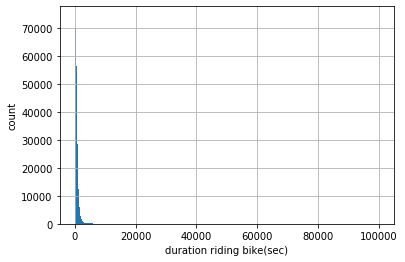

```python
interval = 10
bins = np.arange(50, 100000 + interval, interval)

duration_sec.hist(bins=bins)

plt.xlabel('duration riding bike(sec)')
plt.ylabel('count');
```

Most of the data seems clustered below **20000** sec so it will be helpful to use `log scale`

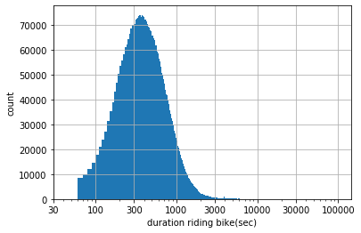

```python
loc = [30, 100, 300, 1000, 3000, 10000, 30000, 100000]
interval = 10
bins = np.arange(50, 100000 + interval, interval)

duration_sec.hist(bins=bins)
plt.xscale('log')
plt.xticks(loc, loc)

# max value is 912110 but I will cut this value to 100000
# Because more then that its outlier
plt.xlabel('duration riding bike(sec)')
plt.ylabel('count');
```

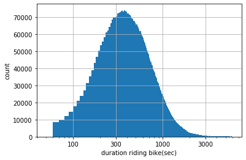

```python
loc = [100, 300, 1000, 3000]
interval = 10
bins = np.arange(50, 6000 + interval, interval)

duration_sec.hist(bins=bins)
plt.xscale('log')
plt.xticks(loc, loc)
plt.xlabel('duration riding bike(sec)')
plt.ylabel('count');
```

```python
# Check which value is at the pick of the distribution
duration_sec.value_counts().index[0]
```

```
370
```

📝 **comment** 🔔 🔎

In the **log scale** if we only consider duration second between `50` and `6000` sec we can see that the graph is showing `normal distribution` and most of the people used bike for `370` second, approximately `6 minutes`.

We looked on the duration time and now let's look at the start and end time using the bike.

### start_time & end_time

- year
- month
- day
- hour

**year**

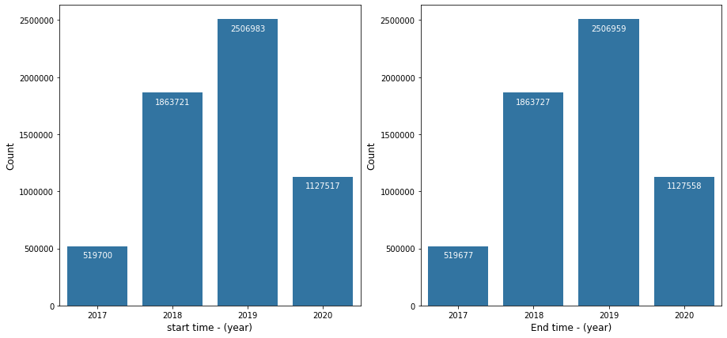

```python
# choose the base color
base_color = sb.color_palette()[0]

# Choose the figure size
plt.figure(figsize=[15, 7])

### START TIME ###
plt.subplot(121)

# Count how many data exist for each start year
start_year = df.start_time.dt.year
start_year_dic = start_year.value_counts()

# make series to dataframe using reset_index()
sb.countplot(data=start_year.reset_index(), x='start_time', color=base_color)
plt.xlabel('start time - (year)', fontsize=12)
plt.ylabel('Count', fontsize=12)

# To show the count value of each
locs, labels = plt.xticks()
for loc, label in zip(locs, labels):
    count = start_year_dic[int(label.get_text())]
    string = str(count)
    plt.text(loc, count-100000, string, ha='center', color='w')

### END TIME ###
plt.subplot(122)

# Count how many data exist for each end year
end_year = df.end_time.dt.year
end_year_dic = end_year.value_counts()

# make series to dataframe using reset_index()
sb.countplot(data=end_year.reset_index(), x='end_time', color=base_color)
plt.xlabel('End time - (year)', fontsize=12)
plt.ylabel('Count', fontsize=12)

# To show the count value of each
locs, labels = plt.xticks()
for loc, label in zip(locs, labels):
    count = end_year_dic[int(label.get_text())]
    string = str(count)
    plt.text(loc, count-100000, string, ha='center', color='w');
```

We can see that 2019 has the most bike usage

**month**

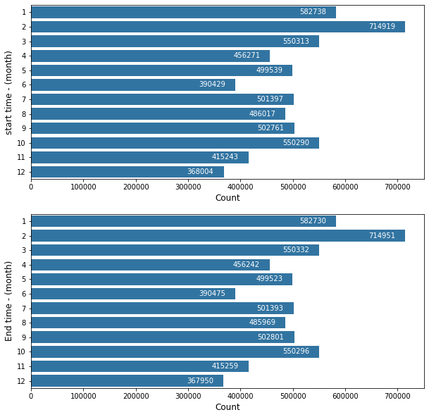

```python
# choose the base color
base_color = sb.color_palette()[0]

# Choose the figure size
plt.figure(figsize=[10, 10])

### START TIME ###
plt.subplot(211)

# Count how many data exist for each start month
start_month = df.start_time.dt.month
start_month_dic = start_month.value_counts()

# make series to dataframe using reset_index()
sb.countplot(data=start_month.reset_index(), y='start_time', color=base_color)
plt.xlabel('Count', fontsize=12)
plt.ylabel('start time - (month)', fontsize=12)


# To show the count value of each
locs, labels = plt.yticks()
for loc, label in zip(locs, labels):
    count = start_month_dic[int(label.get_text())]
    string = str(count)
    plt.text(count-70000, loc, string, va='center', color='w')

### END TIME ###
plt.subplot(212)

# Count how many data exist for each end month
end_month = df.end_time.dt.month
end_month_dic = end_month.value_counts()

# make series to dataframe using reset_index()
sb.countplot(data=end_month.reset_index(), y='end_time', color=base_color)
plt.xlabel('Count', fontsize=12)
plt.ylabel('End time - (month)', fontsize=12)

# To show the count value of each
locs, labels = plt.yticks()
for loc, label in zip(locs, labels):
    count = end_month_dic[int(label.get_text())]
    string = str(count)
    plt.text(count-70000, loc, string, va='center', color='w');
```

We can see that February has the most bike usage

**day**

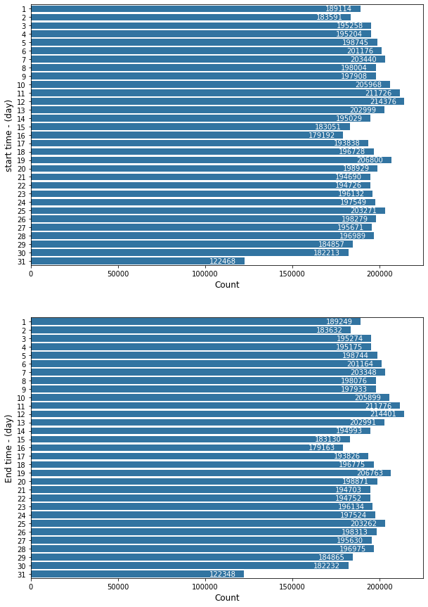

```python
# choose the base color
base_color = sb.color_palette()[0]

# Choose the figure size
plt.figure(figsize=[10, 15])

### START TIME ###
plt.subplot(211)

# Count how many data exist for each start day
start_day = df.start_time.dt.day
start_day_dic = start_day.value_counts()

# make series to dataframe using reset_index()
sb.countplot(data=start_day.reset_index(), y='start_time', color=base_color)
plt.xlabel('Count', fontsize=12)
plt.ylabel('start time - (day)', fontsize=12)


# To show the count value of each
locs, labels = plt.yticks()
for loc, label in zip(locs, labels):
    count = start_day_dic[int(label.get_text())]
    string = str(count)
    plt.text(count-20000, loc, string, va='center', color='w')

### END TIME ###
plt.subplot(212)

# Count how many data exist for each end day
end_day = df.end_time.dt.day
end_day_dic = end_day.value_counts()

# make series to dataframe using reset_index()
sb.countplot(data=end_day.reset_index(), y='end_time', color=base_color)
plt.xlabel('Count', fontsize=12)
plt.ylabel('End time - (day)', fontsize=12)

# To show the count value of each
locs, labels = plt.yticks()
for loc, label in zip(locs, labels):
    count = end_day_dic[int(label.get_text())]
    string = str(count)
    plt.text(count-20000, loc, string, va='center', color='w');
```

We can see that 12th has the most bike usage

**hour**

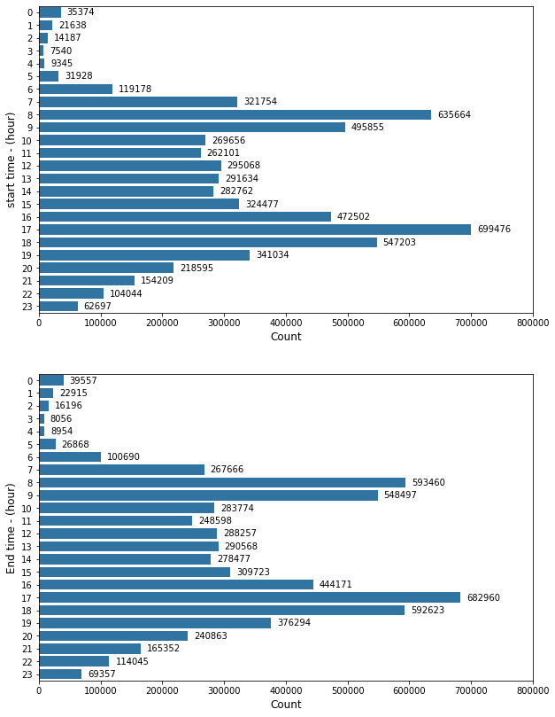

```python
# choose the base color
base_color = sb.color_palette()[0]

# Choose the figure size
plt.figure(figsize=[10, 14])

### START TIME ###
plt.subplot(211)

# Count how many data exist for each start hour
start_hour = df.start_time.dt.hour
start_hour_dic = start_hour.value_counts()

# make series to dataframe using reset_index()
sb.countplot(data=start_hour.reset_index(), y='start_time', color=base_color)
plt.xlabel('Count', fontsize=12)
plt.ylabel('start time - (hour)', fontsize=12)

# To show the count value of each
locs, labels = plt.yticks()
for loc, label in zip(locs, labels):
    count = start_hour_dic[int(label.get_text())]
    string = str(count)
    plt.text(count+10000, loc, string, va='center')

# Add more ticks to put the annotation inside the figure
new_loc = plt.xticks()[0].astype(int)
plt.xticks(new_loc, new_loc)

### END TIME ###
plt.subplot(212)

# Count how many data exist for each end hour
end_hour = df.end_time.dt.hour
end_hour_dic = end_hour.value_counts()

# make series to dataframe using reset_index()
sb.countplot(data=end_hour.reset_index(), y='end_time', color=base_color)
plt.xlabel('Count', fontsize=12)
plt.ylabel('End time - (hour)', fontsize=12)

# To show the count value of each
locs, labels = plt.yticks()
for loc, label in zip(locs, labels):
    count = end_hour_dic[int(label.get_text())]
    string = str(count)
    plt.text(count+10000, loc, string, va='center')

# Add more ticks to put the annotation inside the figure
new_loc = plt.xticks()[0].astype(int)
plt.xticks(new_loc, new_loc);
```

📝 **comment** 🔔 🔎

`Datetime` is qualitative / categorical data so `bar chart` will be good choice. Because the datatime has a lot of values I grouped up to show the insights here.

Now it's time to check where the user started to ride a bike.

### start_station_name & end_station_name

```python
df.start_station_name.value_counts()
```

```
Market St at 10th St                                         101696
San Francisco Ferry Building (Harry Bridges Plaza)            98318
San Francisco Caltrain (Townsend St at 4th St)                95950
Berry St at 4th St                                            95246
San Francisco Caltrain Station 2  (Townsend St at 4th St)     86248
                                                              ...
Howard workshop - Station in a Box                                5
Prototype Lab                                                     4
San Jose Depot                                                    4
Philly Demo                                                       2
SF Test Station                                                   1
Name: start_station_name, Length: 507, dtype: int64
```

```python
df.end_station_name.value_counts()
```

```
San Francisco Caltrain (Townsend St at 4th St)               125580
San Francisco Ferry Building (Harry Bridges Plaza)           117072
San Francisco Caltrain Station 2  (Townsend St at 4th St)    115804
Montgomery St BART Station (Market St at 2nd St)             105912
Market St at 10th St                                          99896
                                                              ...
Bond St at High St                                               11
Howard workshop - Station in a Box                                4
Prototype Lab                                                     4
Emeryville Depot                                                  2
Philly Demo                                                       2
Name: end_station_name, Length: 507, dtype: int64
```

We can see that there is total `507` spot that bike was parked for both start station and end station. We cannot visualize all the stations rather let's choose top 10 popular station and show how many user used it.

```python
start_top10 = list(df.start_station_name.value_counts()[:10].index)
start_top10
```

```
['Market St at 10th St',
 'San Francisco Ferry Building (Harry Bridges Plaza)',
 'San Francisco Caltrain (Townsend St at 4th St)',
 'Berry St at 4th St',
 'San Francisco Caltrain Station 2  (Townsend St at 4th St)',
 'Montgomery St BART Station (Market St at 2nd St)',
 'Powell St BART Station (Market St at 4th St)',
 'The Embarcadero at Sansome St',
 'Howard St at Beale St',
 'Steuart St at Market St']
```

```python
end_top10 = list(df.end_station_name.value_counts()[:10].index)
end_top10
```

```
['San Francisco Caltrain (Townsend St at 4th St)',
 'San Francisco Ferry Building (Harry Bridges Plaza)',
 'San Francisco Caltrain Station 2  (Townsend St at 4th St)',
 'Montgomery St BART Station (Market St at 2nd St)',
 'Market St at 10th St',
 'Berry St at 4th St',
 'The Embarcadero at Sansome St',
 'Powell St BART Station (Market St at 4th St)',
 'Steuart St at Market St',
 'Powell St BART Station (Market St at 5th St)']
```

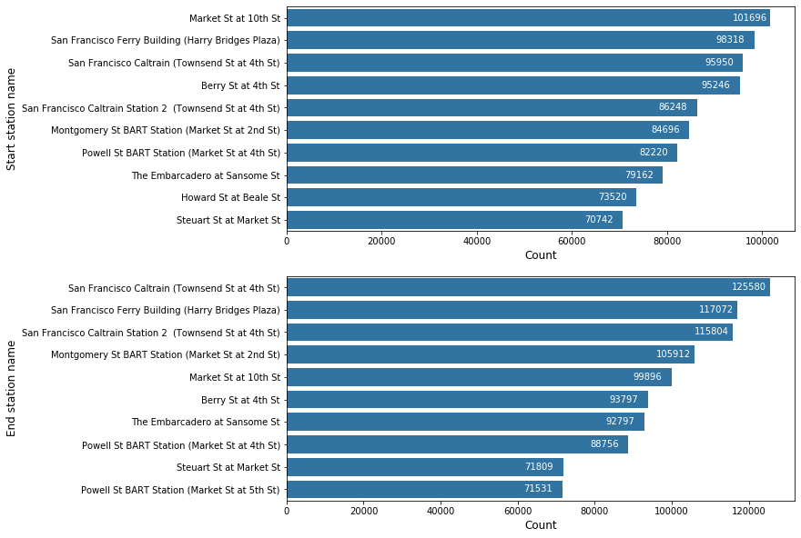

```python
# choose the base color
base_color = sb.color_palette()[0]

# Choose the figure size
plt.figure(figsize=[10, 10])

### START STATION ###
plt.subplot(211)

# Get only top 10 start station
start_df = df.query('start_station_name in @start_top10').start_station_name

# make series to dataframe using reset_index()
sb.countplot(data=start_df.reset_index(), y='start_station_name', color=base_color,
             order=start_top10)
plt.xlabel('Count', fontsize=12)
plt.ylabel('Start station name', fontsize=12)

# To show the count value of each
locs, labels = plt.yticks()
for loc, label in zip(locs, labels):
    # label is not int and we get station name as a string
    # We use this name to get the index from the start_top10
    # which is list containing the station names as decreasing order
    # comparing the total count of usage of each station
    # And this index will be used to get the count number for each station
    count = start_df.value_counts().iloc[start_top10.index(label.get_text())]
    string = str(count)
    plt.text(count-8000, loc, string, va='center', color='w')

### END STATION ###
plt.subplot(212)

# Get only top 10 end station
end_df = df.query('end_station_name in @end_top10').end_station_name

sb.countplot(data=end_df.reset_index(), y='end_station_name', color=base_color,
             order=end_top10)
plt.xlabel('Count', fontsize=12)
plt.ylabel('End station name', fontsize=12)

# To show the count value of each
locs, labels = plt.yticks()
for loc, label in zip(locs, labels):
    count = end_df.value_counts().iloc[end_top10.index(label.get_text())]
    string = str(count)
    plt.text(count-10000, loc, string, va='center', color='w');
```

```python
# intersection
set(start_top10) & set(end_top10)
```

```
{'Berry St at 4th St',
 'Market St at 10th St',
 'Montgomery St BART Station (Market St at 2nd St)',
 'Powell St BART Station (Market St at 4th St)',
 'San Francisco Caltrain (Townsend St at 4th St)',
 'San Francisco Caltrain Station 2  (Townsend St at 4th St)',
 'San Francisco Ferry Building (Harry Bridges Plaza)',
 'Steuart St at Market St',
 'The Embarcadero at Sansome St'}
```

```python
# symmetric difference
set(start_top10) ^ set(end_top10)
```

```
{'Howard St at Beale St', 'Powell St BART Station (Market St at 5th St)'}
```

📝 **comment** 🔔 🔎

We visualized top 10 popular station. We cannot use all the stations so we rather choose to use only 10 of them. `Barplot` was used because this is categorical data.

- total `507` spot that bike was parked for both start station and end station.
- For `start station`, `Market St at 10th St` is the most popular station.
- For `end station`, `San Francisco Caltrain (Townsend St at 4th St)` is the most popular station.
- Start station top 10 and End station top 10 has 9 station the same. This means people mostly start to use bike from here and end here.

This station information could be combined with time data to see which time does people mostly use the bike at specific station. We could make a guess that people using the bike might be an office worker who commutes to and from work.

Now let's look at the `longitude` and `latitude`!

### latitude & longitude

[figure not shown]

```python
# check the start station lat lng range
start_station_lat_range = df.start_station_latitude.min(), df.start_station_latitude.max()
start_station_lng_range = df.start_station_longitude.min(), df.start_station_longitude.max()

# check the end station lat lng range
end_station_lat_range = df.end_station_latitude.min(), df.end_station_latitude.max()
end_station_lng_range = df.end_station_longitude.min(), df.end_station_longitude.max()

# print
print('Start station latitude range : {}'.format(start_station_lat_range))
print('Start station longitude range : {}'.format(start_station_lng_range))
print('End station latitude range : {}'.format(end_station_lat_range))
print('End station longitude range : {}'.format(end_station_lng_range))
```

```
Start station latitude range : (36.1632611667, 45.51)
Start station longitude range : (-122.5143, -73.57)
End station latitude range : (36.16314000000001, 45.51)
End station longitude range : (-122.5757633333, -73.57)
```

```python
# Import patches for Rectangular drawing
import matplotlib.patches as patches
import urllib
```

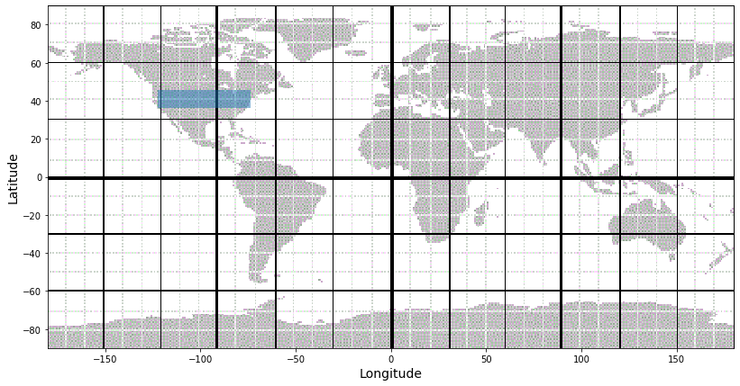

```python
fig = plt.figure(figsize=[15, 7])

# Add subplot for drawing rectangular
ax = fig.add_subplot(111)

width = start_station_lng_range[1] - start_station_lng_range[0]
height = start_station_lat_range[1] - start_station_lat_range[0]
ax.add_patch(patches.Rectangle((start_station_lng_range[0], start_station_lat_range[0]), width, height, alpha=0.5))

plt.xlim((-180, 180))
plt.ylim((-90, 90))

# create an file object from the url
f = urllib.request.urlopen('https://www.satsig.net/world105.gif')

# Read the file object and convert to np.array
image = plt.imread(f, format='gif')

# Manual xlim ylim tuning
ax.imshow(image, extent=[-271, 229, -147, 105])

plt.xlim((-180, 180))
plt.ylim((-90, 90))

plt.xlabel('Longitude', fontsize=14)
plt.ylabel('Latitude', fontsize=14);
```

The **blue rectangle** shows the location where the service of lyft bike sharing operates. We can see that the range is quite broad and limited to USA.

But actually this is not right. The service is limited to `California`.

**Lyft bike station**

- San Francisco
- East Bay
- San Jose

We could consider there is some noise inside the `longitude` and `latitude` data. Let's remove the wrong data after explore.

```python
start_lng = df.start_station_longitude[~df.start_station_longitude.isna()]
start_lat = df.start_station_latitude[~df.start_station_latitude.isna()]
```

```python
# check the values
start_lng.value_counts()
```

```
-122.417385    99613
-122.394203    97388
-122.395282    95309
-122.393170    94197
-122.395526    86248
               ...
-122.442428        1
-121.874899        1
-121.891765        1
-122.441644        1
-122.408732        1
Name: start_station_longitude, Length: 341459, dtype: int64
```

```python
# Most of the values are below 10
(start_lng.value_counts() < 10).mean()
```

```
0.9920868976948917
```

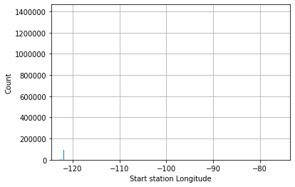

```python
interval = 0.01
bins = np.arange(start_station_lng_range[0] - 1, start_station_lng_range[1] + interval, interval)
start_lng.hist(bins=bins)

plt.xlim(start_station_lng_range[0] - 2, start_station_lng_range[1] + interval)
plt.xlabel('Start station Longitude')
plt.ylabel('Count');
```

We can see that most of the values are spread widely and the counts are less than 10 so we can hardly see some values here. Rather we choose to look at the range that most values appear

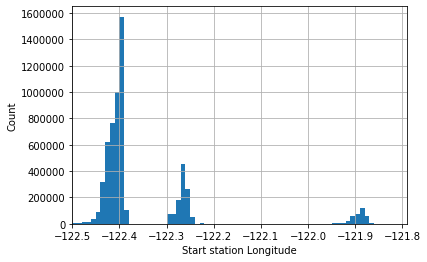

```python
interval = 0.01

# start station longitude
bins = np.arange(-122.5, -121.8 + interval, interval)
start_lng.hist(bins=bins)
plt.xlim(-122.5, -121.8 + interval)
plt.xlabel('Start station Longitude')
plt.ylabel('Count');
```

We can see most of the `start station bike usage` is around **longitude** `-122.39`, `-122.28`, and `-121.88`

```python
start_lat.value_counts()
```

```
37.776619    99616
37.795392    97387
37.776598    95310
37.775880    94196
37.776639    86248
             ...
37.327266        1
37.805391        1
37.731287        1
37.346996        1
37.782207        1
Name: start_station_latitude, Length: 321217, dtype: int64
```

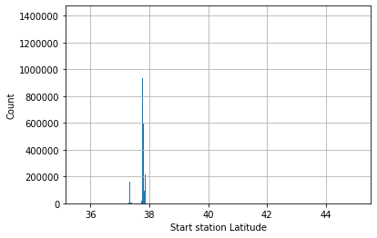

```python
interval = 0.01
bins = np.arange(start_station_lat_range[0] - 1, start_station_lat_range[1] + interval, interval)
start_lat.hist(bins=bins)

plt.xlim(start_station_lat_range[0] - 1, start_station_lat_range[1] + interval)
plt.xlabel('Start station Latitude')
plt.ylabel('Count');
```

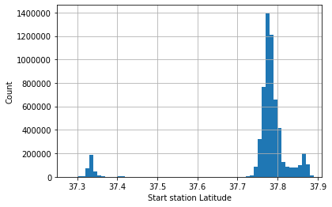

```python
interval = 0.01
bins = np.arange(37.25, 37.9 + interval, interval)
start_lat.hist(bins=bins)

plt.xlim(37.25, 37.9 + interval)
plt.xlabel('Start station Latitude')
plt.ylabel('Count');
```

We can see most of the `start station bike usage` is around **latitude** `37.33` and `37.77`

Now let's look at end station `longitude` and `latitude`. The pattern will be very similar to upward because the bike is not a method for a long ride and most of the users ride around **6 minutes**!

```python
end_lng = df.end_station_longitude[~df.end_station_longitude.isna()]
end_lat = df.end_station_latitude[~df.end_station_latitude.isna()]
```

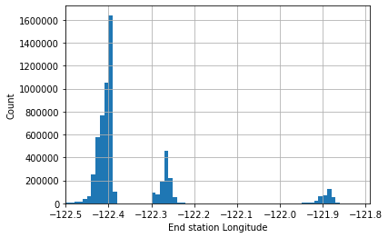

```python
interval = 0.01

# end station longitude
bins = np.arange(-122.5, -121.8 + interval, interval)
end_lng.hist(bins=bins)
plt.xlim(-122.5, -121.8 + interval)
plt.xlabel('End station Longitude')
plt.ylabel('Count');
```

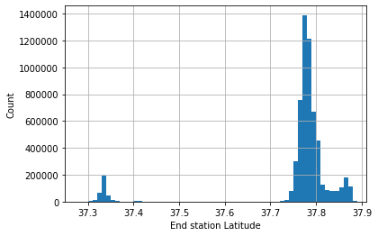

```python
interval = 0.01
bins = np.arange(37.25, 37.9 + interval, interval)
end_lat.hist(bins=bins)

plt.xlim(37.25, 37.9 + interval)
plt.xlabel('End station Latitude')
plt.ylabel('Count');
```

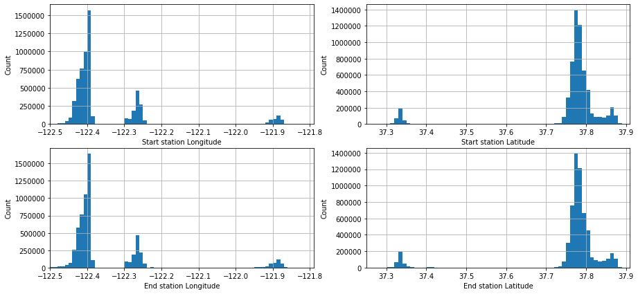

```python
plt.figure(figsize=[15, 7])

interval = 0.01

# start station longitude
plt.subplot(221)

bins = np.arange(-122.5, -121.8 + interval, interval)
start_lng.hist(bins=bins)

plt.xlim(-122.5, -121.8 + interval)
plt.xlabel('Start station Longitude')
plt.ylabel('Count')

# start station latitude
plt.subplot(222)

bins = np.arange(37.25, 37.9 + interval, interval)
start_lat.hist(bins=bins)

plt.xlim(37.25, 37.9 + interval)
plt.xlabel('Start station Latitude')
plt.ylabel('Count')

# end station longitude
plt.subplot(223)

bins = np.arange(-122.5, -121.8 + interval, interval)
end_lng.hist(bins=bins)
plt.xlim(-122.5, -121.8 + interval)
plt.xlabel('End station Longitude')
plt.ylabel('Count')

# end station latitude
plt.subplot(224)

bins = np.arange(37.25, 37.9 + interval, interval)
end_lat.hist(bins=bins)

plt.xlim(37.25, 37.9 + interval)
plt.xlabel('End station Latitude')
plt.ylabel('Count');
```

We explored the data and now we know that there is 3 spots that most of the bikes are located.

Let's check how many data is above this area and which place is it.

```python
df.query('start_station_longitude > -120')
```

|  | duration_sec | start_time | end_time | start_station_id | start_station_name | start_station_latitude | start_station_longitude | end_station_id | end_station_name | end_station_latitude | end_station_longitude | bike_id | user_type | bike_share_for_all_trip | rental_access_method | rideable_type | is_equity |
| --- | --- | --- | --- | --- | --- | --- | --- | --- | --- | --- | --- | --- | --- | --- | --- | --- | --- |
| 1153196 | 283 | 2018-06-29 08:57:14.525 | 2018-06-29 09:01:57.582 | NaN | NaN | 45.510000 | -73.570000 | NaN | NaN | 45.510000 | -73.570000 | 4295 | Subscriber | No | NaN | NaN | NaN |
| 1174814 | 12944 | 2018-06-26 10:59:12.446 | 2018-06-26 14:34:57.186 | NaN | NaN | 44.950000 | -93.220000 | NaN | NaN | 44.950000 | -93.220000 | 3758 | Subscriber | No | NaN | NaN | NaN |
| 1199788 | 1443 | 2018-06-22 13:36:13.056 | 2018-06-22 14:00:16.996 | NaN | NaN | 45.510000 | -73.570000 | NaN | NaN | 45.510000 | -73.570000 | 4295 | Subscriber | No | NaN | NaN | NaN |
| 1277552 | 191 | 2018-06-11 08:23:37.019 | 2018-06-11 08:26:48.599 | NaN | NaN | 45.510000 | -73.570000 | NaN | NaN | 45.510000 | -73.570000 | 4295 | Subscriber | No | NaN | NaN | NaN |
| 1335753 | 69 | 2018-06-01 13:56:04.027 | 2018-06-01 13:57:13.648 | NaN | NaN | 40.660000 | -74.010000 | NaN | NaN | 40.660000 | -74.010000 | 4297 | Subscriber | No | NaN | NaN | NaN |
| 1335770 | 126 | 2018-06-01 13:51:52.771 | 2018-06-01 13:53:58.967 | NaN | NaN | 40.660000 | -74.010000 | NaN | NaN | 40.660000 | -74.010000 | 4297 | Subscriber | No | NaN | NaN | NaN |
| 1335791 | 67 | 2018-06-01 13:47:53.131 | 2018-06-01 13:49:00.368 | NaN | NaN | 40.660000 | -74.010000 | NaN | NaN | 40.660000 | -74.010000 | 4297 | Subscriber | No | NaN | NaN | NaN |
| 1604948 | 501 | 2018-08-21 12:11:52.500 | 2018-08-21 12:20:13.500 | NaN | NaN | 45.500000 | -73.570000 | NaN | NaN | 45.510000 | -73.570000 | 4425 | Subscriber | No | NaN | NaN | NaN |
| 1611788 | 1023 | 2018-08-20 12:07:06.500 | 2018-08-20 12:24:09.500 | NaN | NaN | 45.500000 | -73.570000 | NaN | NaN | 45.510000 | -73.570000 | 4425 | Subscriber | No | NaN | NaN | NaN |
| 1612386 | 94 | 2018-08-20 09:53:14.500 | 2018-08-20 09:54:48.500 | NaN | NaN | 45.510000 | -73.570000 | NaN | NaN | 45.510000 | -73.570000 | 4425 | Subscriber | No | NaN | NaN | NaN |
| 1653836 | 3781 | 2018-08-13 11:23:24.700 | 2018-08-13 12:26:25.840 | NaN | NaN | 44.950000 | -93.220000 | NaN | NaN | 44.950000 | -93.220000 | 3763 | Subscriber | No | NaN | NaN | NaN |
| 3457622 | 4212 | 2019-06-27 07:31:51.684 | 2019-06-27 08:42:04.399 | 408 | MTL-ECO5-01 | 45.510000 | -73.570000 | 408 | MTL-ECO5-01 | 45.510000 | -73.570000 | 6733 | Subscriber | No | NaN | NaN | NaN |
| 4016956 | 3885 | 2019-08-13 11:08:07.325 | 2019-08-13 12:12:52.507 | 408 | MTL-ECO5-01 | 45.510000 | -73.570000 | 408 | MTL-ECO5-01 | 45.510000 | -73.570000 | 6733 | Subscriber | No | NaN | NaN | NaN |
| 4086340 | 335 | 2019-08-02 14:03:06.648 | 2019-08-02 14:08:41.900 | 408 | MTL-ECO5-01 | 45.510000 | -73.570000 | 408 | MTL-ECO5-01 | 45.510000 | -73.570000 | 6733 | Subscriber | No | NaN | NaN | NaN |
| 4094221 | 348 | 2019-08-01 10:50:05.912 | 2019-08-01 10:55:54.012 | 408 | MTL-ECO5-01 | 45.510000 | -73.570000 | 408 | MTL-ECO5-01 | 45.510000 | -73.570000 | 6733 | Subscriber | No | NaN | NaN | NaN |
| 4638787 | 378 | 2019-11-15 07:26:55.959 | 2019-11-15 07:33:14.499 | 484 | Philly Demo | 39.892567 | -75.173714 | 484 | Philly Demo | 39.892567 | -75.173714 | 12374 | Customer | No | NaN | NaN | NaN |
| 4639154 | 95 | 2019-11-15 05:19:32.156 | 2019-11-15 05:21:07.925 | 484 | Philly Demo | 39.892567 | -75.173714 | 484 | Philly Demo | 39.892567 | -75.173714 | 12374 | Customer | No | NaN | NaN | NaN |
| 4738903 | 261 | 2019-11-21 13:29:51.000 | 2019-11-21 13:34:13.000 | NaN | NaN | 36.163261 | -86.775812 | NaN | NaN | 36.163580 | -86.775177 | 544723 | Subscriber | NaN | clipper | NaN | NaN |
| 4738904 | 1285 | 2019-11-14 09:20:46.000 | 2019-11-14 09:42:11.000 | NaN | NaN | 36.163307 | -86.775634 | NaN | NaN | 36.163385 | -86.775794 | 544723 | Subscriber | NaN | app | NaN | NaN |
| 4738905 | 1359 | 2019-11-06 10:38:51.000 | 2019-11-06 11:01:31.000 | NaN | NaN | 36.163311 | -86.776018 | NaN | NaN | 36.163421 | -86.775728 | 544723 | Subscriber | NaN | app | NaN | NaN |
| 4738906 | 208 | 2019-11-21 13:15:47.000 | 2019-11-21 13:19:16.000 | NaN | NaN | 36.163449 | -86.775769 | NaN | NaN | 36.163460 | -86.775805 | 544723 | Subscriber | NaN | clipper | NaN | NaN |
| 4738907 | 471 | 2019-11-21 13:34:26.000 | 2019-11-21 13:42:18.000 | NaN | NaN | 36.163580 | -86.775177 | NaN | NaN | 36.163140 | -86.775855 | 544723 | Subscriber | NaN | clipper | NaN | NaN |

```python
df.query('end_station_longitude > -120')
```

|  | duration_sec | start_time | end_time | start_station_id | start_station_name | start_station_latitude | start_station_longitude | end_station_id | end_station_name | end_station_latitude | end_station_longitude | bike_id | user_type | bike_share_for_all_trip | rental_access_method | rideable_type | is_equity |
| --- | --- | --- | --- | --- | --- | --- | --- | --- | --- | --- | --- | --- | --- | --- | --- | --- | --- |
| 1153196 | 283 | 2018-06-29 08:57:14.525 | 2018-06-29 09:01:57.582 | NaN | NaN | 45.510000 | -73.570000 | NaN | NaN | 45.510000 | -73.570000 | 4295 | Subscriber | No | NaN | NaN | NaN |
| 1174814 | 12944 | 2018-06-26 10:59:12.446 | 2018-06-26 14:34:57.186 | NaN | NaN | 44.950000 | -93.220000 | NaN | NaN | 44.950000 | -93.220000 | 3758 | Subscriber | No | NaN | NaN | NaN |
| 1199788 | 1443 | 2018-06-22 13:36:13.056 | 2018-06-22 14:00:16.996 | NaN | NaN | 45.510000 | -73.570000 | NaN | NaN | 45.510000 | -73.570000 | 4295 | Subscriber | No | NaN | NaN | NaN |
| 1277552 | 191 | 2018-06-11 08:23:37.019 | 2018-06-11 08:26:48.599 | NaN | NaN | 45.510000 | -73.570000 | NaN | NaN | 45.510000 | -73.570000 | 4295 | Subscriber | No | NaN | NaN | NaN |
| 1335753 | 69 | 2018-06-01 13:56:04.027 | 2018-06-01 13:57:13.648 | NaN | NaN | 40.660000 | -74.010000 | NaN | NaN | 40.660000 | -74.010000 | 4297 | Subscriber | No | NaN | NaN | NaN |
| 1335770 | 126 | 2018-06-01 13:51:52.771 | 2018-06-01 13:53:58.967 | NaN | NaN | 40.660000 | -74.010000 | NaN | NaN | 40.660000 | -74.010000 | 4297 | Subscriber | No | NaN | NaN | NaN |
| 1335791 | 67 | 2018-06-01 13:47:53.131 | 2018-06-01 13:49:00.368 | NaN | NaN | 40.660000 | -74.010000 | NaN | NaN | 40.660000 | -74.010000 | 4297 | Subscriber | No | NaN | NaN | NaN |
| 1604948 | 501 | 2018-08-21 12:11:52.500 | 2018-08-21 12:20:13.500 | NaN | NaN | 45.500000 | -73.570000 | NaN | NaN | 45.510000 | -73.570000 | 4425 | Subscriber | No | NaN | NaN | NaN |
| 1611788 | 1023 | 2018-08-20 12:07:06.500 | 2018-08-20 12:24:09.500 | NaN | NaN | 45.500000 | -73.570000 | NaN | NaN | 45.510000 | -73.570000 | 4425 | Subscriber | No | NaN | NaN | NaN |
| 1612386 | 94 | 2018-08-20 09:53:14.500 | 2018-08-20 09:54:48.500 | NaN | NaN | 45.510000 | -73.570000 | NaN | NaN | 45.510000 | -73.570000 | 4425 | Subscriber | No | NaN | NaN | NaN |
| 1653836 | 3781 | 2018-08-13 11:23:24.700 | 2018-08-13 12:26:25.840 | NaN | NaN | 44.950000 | -93.220000 | NaN | NaN | 44.950000 | -93.220000 | 3763 | Subscriber | No | NaN | NaN | NaN |
| 3457622 | 4212 | 2019-06-27 07:31:51.684 | 2019-06-27 08:42:04.399 | 408 | MTL-ECO5-01 | 45.510000 | -73.570000 | 408 | MTL-ECO5-01 | 45.510000 | -73.570000 | 6733 | Subscriber | No | NaN | NaN | NaN |
| 4016956 | 3885 | 2019-08-13 11:08:07.325 | 2019-08-13 12:12:52.507 | 408 | MTL-ECO5-01 | 45.510000 | -73.570000 | 408 | MTL-ECO5-01 | 45.510000 | -73.570000 | 6733 | Subscriber | No | NaN | NaN | NaN |
| 4086340 | 335 | 2019-08-02 14:03:06.648 | 2019-08-02 14:08:41.900 | 408 | MTL-ECO5-01 | 45.510000 | -73.570000 | 408 | MTL-ECO5-01 | 45.510000 | -73.570000 | 6733 | Subscriber | No | NaN | NaN | NaN |
| 4094221 | 348 | 2019-08-01 10:50:05.912 | 2019-08-01 10:55:54.012 | 408 | MTL-ECO5-01 | 45.510000 | -73.570000 | 408 | MTL-ECO5-01 | 45.510000 | -73.570000 | 6733 | Subscriber | No | NaN | NaN | NaN |
| 4638787 | 378 | 2019-11-15 07:26:55.959 | 2019-11-15 07:33:14.499 | 484 | Philly Demo | 39.892567 | -75.173714 | 484 | Philly Demo | 39.892567 | -75.173714 | 12374 | Customer | No | NaN | NaN | NaN |
| 4639154 | 95 | 2019-11-15 05:19:32.156 | 2019-11-15 05:21:07.925 | 484 | Philly Demo | 39.892567 | -75.173714 | 484 | Philly Demo | 39.892567 | -75.173714 | 12374 | Customer | No | NaN | NaN | NaN |
| 4738903 | 261 | 2019-11-21 13:29:51.000 | 2019-11-21 13:34:13.000 | NaN | NaN | 36.163261 | -86.775812 | NaN | NaN | 36.163580 | -86.775177 | 544723 | Subscriber | NaN | clipper | NaN | NaN |
| 4738904 | 1285 | 2019-11-14 09:20:46.000 | 2019-11-14 09:42:11.000 | NaN | NaN | 36.163307 | -86.775634 | NaN | NaN | 36.163385 | -86.775794 | 544723 | Subscriber | NaN | app | NaN | NaN |
| 4738905 | 1359 | 2019-11-06 10:38:51.000 | 2019-11-06 11:01:31.000 | NaN | NaN | 36.163311 | -86.776018 | NaN | NaN | 36.163421 | -86.775728 | 544723 | Subscriber | NaN | app | NaN | NaN |
| 4738906 | 208 | 2019-11-21 13:15:47.000 | 2019-11-21 13:19:16.000 | NaN | NaN | 36.163449 | -86.775769 | NaN | NaN | 36.163460 | -86.775805 | 544723 | Subscriber | NaN | clipper | NaN | NaN |
| 4738907 | 471 | 2019-11-21 13:34:26.000 | 2019-11-21 13:42:18.000 | NaN | NaN | 36.163580 | -86.775177 | NaN | NaN | 36.163140 | -86.775855 | 544723 | Subscriber | NaN | clipper | NaN | NaN |

```python
df.query('start_station_latitude > 38')
```

|  | duration_sec | start_time | end_time | start_station_id | start_station_name | start_station_latitude | start_station_longitude | end_station_id | end_station_name | end_station_latitude | end_station_longitude | bike_id | user_type | bike_share_for_all_trip | rental_access_method | rideable_type | is_equity |
| --- | --- | --- | --- | --- | --- | --- | --- | --- | --- | --- | --- | --- | --- | --- | --- | --- | --- |
| 1153196 | 283 | 2018-06-29 08:57:14.525 | 2018-06-29 09:01:57.582 | NaN | NaN | 45.510000 | -73.570000 | NaN | NaN | 45.510000 | -73.570000 | 4295 | Subscriber | No | NaN | NaN | NaN |
| 1174814 | 12944 | 2018-06-26 10:59:12.446 | 2018-06-26 14:34:57.186 | NaN | NaN | 44.950000 | -93.220000 | NaN | NaN | 44.950000 | -93.220000 | 3758 | Subscriber | No | NaN | NaN | NaN |
| 1199788 | 1443 | 2018-06-22 13:36:13.056 | 2018-06-22 14:00:16.996 | NaN | NaN | 45.510000 | -73.570000 | NaN | NaN | 45.510000 | -73.570000 | 4295 | Subscriber | No | NaN | NaN | NaN |
| 1277552 | 191 | 2018-06-11 08:23:37.019 | 2018-06-11 08:26:48.599 | NaN | NaN | 45.510000 | -73.570000 | NaN | NaN | 45.510000 | -73.570000 | 4295 | Subscriber | No | NaN | NaN | NaN |
| 1335753 | 69 | 2018-06-01 13:56:04.027 | 2018-06-01 13:57:13.648 | NaN | NaN | 40.660000 | -74.010000 | NaN | NaN | 40.660000 | -74.010000 | 4297 | Subscriber | No | NaN | NaN | NaN |
| 1335770 | 126 | 2018-06-01 13:51:52.771 | 2018-06-01 13:53:58.967 | NaN | NaN | 40.660000 | -74.010000 | NaN | NaN | 40.660000 | -74.010000 | 4297 | Subscriber | No | NaN | NaN | NaN |
| 1335791 | 67 | 2018-06-01 13:47:53.131 | 2018-06-01 13:49:00.368 | NaN | NaN | 40.660000 | -74.010000 | NaN | NaN | 40.660000 | -74.010000 | 4297 | Subscriber | No | NaN | NaN | NaN |
| 1604948 | 501 | 2018-08-21 12:11:52.500 | 2018-08-21 12:20:13.500 | NaN | NaN | 45.500000 | -73.570000 | NaN | NaN | 45.510000 | -73.570000 | 4425 | Subscriber | No | NaN | NaN | NaN |
| 1611788 | 1023 | 2018-08-20 12:07:06.500 | 2018-08-20 12:24:09.500 | NaN | NaN | 45.500000 | -73.570000 | NaN | NaN | 45.510000 | -73.570000 | 4425 | Subscriber | No | NaN | NaN | NaN |
| 1612386 | 94 | 2018-08-20 09:53:14.500 | 2018-08-20 09:54:48.500 | NaN | NaN | 45.510000 | -73.570000 | NaN | NaN | 45.510000 | -73.570000 | 4425 | Subscriber | No | NaN | NaN | NaN |
| 1653836 | 3781 | 2018-08-13 11:23:24.700 | 2018-08-13 12:26:25.840 | NaN | NaN | 44.950000 | -93.220000 | NaN | NaN | 44.950000 | -93.220000 | 3763 | Subscriber | No | NaN | NaN | NaN |
| 3457622 | 4212 | 2019-06-27 07:31:51.684 | 2019-06-27 08:42:04.399 | 408 | MTL-ECO5-01 | 45.510000 | -73.570000 | 408 | MTL-ECO5-01 | 45.510000 | -73.570000 | 6733 | Subscriber | No | NaN | NaN | NaN |
| 4016956 | 3885 | 2019-08-13 11:08:07.325 | 2019-08-13 12:12:52.507 | 408 | MTL-ECO5-01 | 45.510000 | -73.570000 | 408 | MTL-ECO5-01 | 45.510000 | -73.570000 | 6733 | Subscriber | No | NaN | NaN | NaN |
| 4086340 | 335 | 2019-08-02 14:03:06.648 | 2019-08-02 14:08:41.900 | 408 | MTL-ECO5-01 | 45.510000 | -73.570000 | 408 | MTL-ECO5-01 | 45.510000 | -73.570000 | 6733 | Subscriber | No | NaN | NaN | NaN |
| 4094221 | 348 | 2019-08-01 10:50:05.912 | 2019-08-01 10:55:54.012 | 408 | MTL-ECO5-01 | 45.510000 | -73.570000 | 408 | MTL-ECO5-01 | 45.510000 | -73.570000 | 6733 | Subscriber | No | NaN | NaN | NaN |
| 4638787 | 378 | 2019-11-15 07:26:55.959 | 2019-11-15 07:33:14.499 | 484 | Philly Demo | 39.892567 | -75.173714 | 484 | Philly Demo | 39.892567 | -75.173714 | 12374 | Customer | No | NaN | NaN | NaN |
| 4639154 | 95 | 2019-11-15 05:19:32.156 | 2019-11-15 05:21:07.925 | 484 | Philly Demo | 39.892567 | -75.173714 | 484 | Philly Demo | 39.892567 | -75.173714 | 12374 | Customer | No | NaN | NaN | NaN |